# Modelo Predictivo: Abandono de Clientes

Proyecto Fuga de Clientes

Alejandro Rojas Moreno

9/12/2021

# Presentación

En este proyecto se analizará la información de una base de datos referente a créditos a personas físicas, con el objetivo de identificar los factores que contribuyen en mayor medida a predecir la pérdida o fuga de clientes, así como estimar el periodo de tiempo antes de que ocurra el abandono.

Se iniciará con un análisis exploratorio para conocer la estructura de la información así como también identificar si existen valores faltantes. Lo anterior, servirá para irnos familiarizando con la información.

Se utilizarán varios algoritmos de **Aprendizaje Supervisado** para precedir la deserción, ya que es recomendable hacer comparaciones entre varios modelos, además, se irán identificando los factores más importantes que explican la fuga de clientes. También, se creará un modelo de **ensamble** como solución alternativa y se compararán sus resultados con los del mejor modelo.

Finalmente, se construirá un modelo para predecir el tiempo o momento de abandono.

Los datos para este análisis provienen del repositorio de aprendizaje automático de [kaggle](https://www.kaggle.com/adammaus/predicting-churn-for-bank-customers#), que es un sitio web para la comunidad de **data science**, donde se pueden encontrar bases de datos para practicar y competir en proyectos. También, se encuentran en mi repositorio de [github](https://github.com/arojasmor/FugaClientes) junto con el código de esta publicación.

# Contenido

- Presentación
- Contenido
- Set up
- Carga y preparación de los datos
- Análisis exploratorio
- Pre procesamiento de los datos
  - Selección de variables
  - Codificación de variables categóricas
  - Escalamiento
  - Balanceo de clases
- Métrica de evaluación
- Creación de modelos de aprendizaje automático
  - Modelo base: Naive Bayes
  - Regresión Logística
  - Máquinas de Vectores Soporte
  - Random Forest
  - Extreme Gradient Boosting (XGBoost)
  - Redes Neuronales (RNN)
  - Gradient Boosting Machine (GBM)
- Comparación de modelos
- Evaluación con datos de validación
- Importancia de las variables
- Ensamble
- Elección del valor de corte adecuado
- Evaluación final: datos de test
- Identificando el tiempo de abandono del cliente
- Conclusiones

# Set up

Iniciamos configurando las opciones generales que vamos a requerir para el desarrollo de este proyecto.

```r
knitr::opts_chunk$set(echo = TRUE,
                      warning = FALSE,
                      message = FALSE,
                      warning = FALSE,
                      fig.align = "center"
                      )


paquetes <- c("knitr","tidyverse","ggplot2","gridExtra","DataExplorer","lubridate",
              "scales","rpart","rpart.plot","kableExtra", "summarytools", "DT", "ggpubr",
              "sfo", "plyr", "plotly", "psych", "janitor", "purrr", "caret", "ROSE", "klaR",
              "parallel", "doSNOW", "recipes", "ranger", "randomForest", "ggthemes", "ROCR",
              "sjPlot", "survival", "survminer", "pec")

instalados <- paquetes %in% installed.packages()

if(sum(instalados == FALSE) > 0) {
  install.packages(paquetes[!instalados])
}

lapply(paquetes, require, character.only = TRUE)

# se cargan funciones
source("cutoff.R")
```

# Carga y preparación de los datos

Comencemos por cargar el conjunto de datos y hacer un primer análisis descriptivo básico para tener una idea de su tamaño y el tipo de cada variable.

```r
creditos <- read_csv("Churn_Modelling.csv")

creditos.raw <- creditos # para usarse al final con el modelo de permanencia

str(creditos)
```

```
## spec_tbl_df [10,000 x 14] (S3: spec_tbl_df/tbl_df/tbl/data.frame)
##  $ RowNumber      : num [1:10000] 1 2 3 4 5 6 7 8 9 10 ...
##  $ CustomerId     : num [1:10000] 15634602 15647311 15619304 15701354 15737888 ...
##  $ Surname        : chr [1:10000] "Hargrave" "Hill" "Onio" "Boni" ...
##  $ CreditScore    : num [1:10000] 619 608 502 699 850 645 822 376 501 684 ...
##  $ Geography      : chr [1:10000] "France" "Spain" "France" "France" ...
##  $ Gender         : chr [1:10000] "Female" "Female" "Female" "Female" ...
##  $ Age            : num [1:10000] 42 41 42 39 43 44 50 29 44 27 ...
##  $ Tenure         : num [1:10000] 2 1 8 1 2 8 7 4 4 2 ...
##  $ Balance        : num [1:10000] 0 83808 159661 0 125511 ...
##  $ NumOfProducts  : num [1:10000] 1 1 3 2 1 2 2 4 2 1 ...
##  $ HasCrCard      : num [1:10000] 1 0 1 0 1 1 1 1 0 1 ...
##  $ IsActiveMember : num [1:10000] 1 1 0 0 1 0 1 0 1 1 ...
##  $ EstimatedSalary: num [1:10000] 101349 112543 113932 93827 79084 ...
##  $ Exited         : num [1:10000] 1 0 1 0 0 1 0 1 0 0 ...
##  - attr(*, "spec")=
##   .. cols(
##   ..   RowNumber = col_double(),
##   ..   CustomerId = col_double(),
##   ..   Surname = col_character(),
##   ..   CreditScore = col_double(),
##   ..   Geography = col_character(),
##   ..   Gender = col_character(),
##   ..   Age = col_double(),
##   ..   Tenure = col_double(),
##   ..   Balance = col_double(),
##   ..   NumOfProducts = col_double(),
##   ..   HasCrCard = col_double(),
##   ..   IsActiveMember = col_double(),
##   ..   EstimatedSalary = col_double(),
##   ..   Exited = col_double()
##   .. )
```

```r
DT::datatable(head(creditos, 20),
              rownames = FALSE,
              options = list(
                pageLength = 5,
                scrollX = TRUE))
```

| RowNumber | CustomerId | Surname | CreditScore | Geography | Gender | Age | Tenure | Balance | NumOfProducts | HasCrCard | IsActiveMember | EstimatedSalary | Exited |
| --- | --- | --- | --- | --- | --- | --- | --- | --- | --- | --- | --- | --- | --- |
| 1 | 15634602 | Hargrave | 619 | France | Female | 42 | 2 | 0 | 1 | 1 | 1 | 101348.88 | 1 |
| 2 | 15647311 | Hill | 608 | Spain | Female | 41 | 1 | 83807.86 | 1 | 0 | 1 | 112542.58 | 0 |
| 3 | 15619304 | Onio | 502 | France | Female | 42 | 8 | 159660.8 | 3 | 1 | 0 | 113931.57 | 1 |
| 4 | 15701354 | Boni | 699 | France | Female | 39 | 1 | 0 | 2 | 0 | 0 | 93826.63 | 0 |
| 5 | 15737888 | Mitchell | 850 | Spain | Female | 43 | 2 | 125510.82 | 1 | 1 | 1 | 79084.1 | 0 |
| 6 | 15574012 | Chu | 645 | Spain | Male | 44 | 8 | 113755.78 | 2 | 1 | 0 | 149756.71 | 1 |
| 7 | 15592531 | Bartlett | 822 | France | Male | 50 | 7 | 0 | 2 | 1 | 1 | 10062.8 | 0 |
| 8 | 15656148 | Obinna | 376 | Germany | Female | 29 | 4 | 115046.74 | 4 | 1 | 0 | 119346.88 | 1 |
| 9 | 15792365 | He | 501 | France | Male | 44 | 4 | 142051.07 | 2 | 0 | 1 | 74940.5 | 0 |
| 10 | 15592389 | H? | 684 | France | Male | 27 | 2 | 134603.88 | 1 | 1 | 1 | 71725.73 | 0 |

[output cut: 10 more lines]

Tenemos una base de 10,000 registros y 14 columnas, de las cuales solo 3 son de tipo character y el resto numéricas.

La última característica, ‘Exited’, es la variable objetivo e indica si el cliente se ha ido o abandonado la institución (0 = No, 1 = Sí).

# Análisis exploratorio

Empecemos el análisis exploratorio identificando si hay datos faltantes y si los hay debemos conocer cuántos son y en qué variables:

```r
creditos %>%
  summarise_all(~sum(is.na(.))) %>%
  t()
```

```
##                 [,1]
## RowNumber          0
## CustomerId         0
## Surname            0
## CreditScore        0
## Geography          0
## Gender             0
## Age                0
## Tenure             0
## Balance            0
## NumOfProducts      0
## HasCrCard          0
## IsActiveMember     0
## EstimatedSalary    0
## Exited             0
```

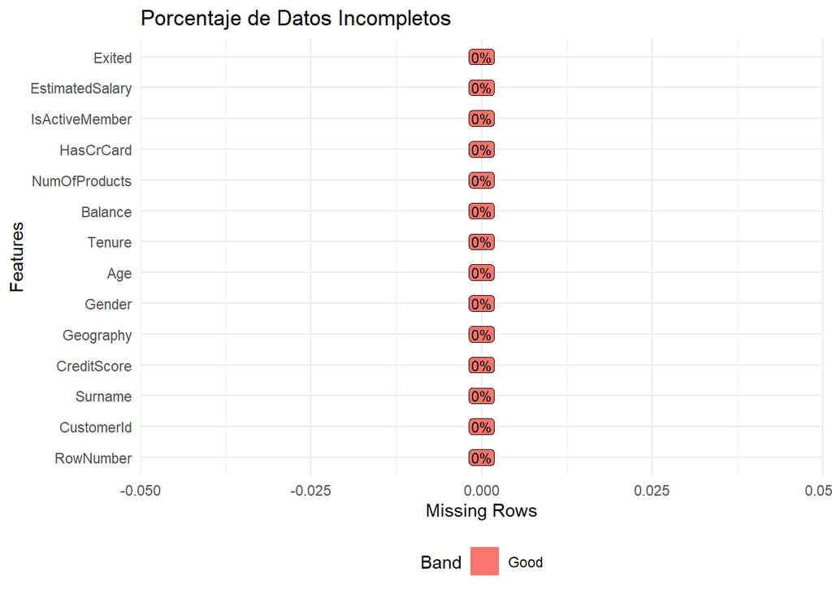

```r
plot_missing(creditos, title = "Porcentaje de Datos Incompletos",
             geom_label_args = list("size" = 3, "label.padding" = unit(0.1, "lines")),
             ggtheme = theme_minimal())
```

Los resultados anteriores y la gráfica muestran que en la base de datos no hay observaciones faltantes. Esto es buena noticia, ya que no tendremos que hacer ninguna imputación. Sin embargo, debemos checar, también, que no haya valores “NULL” en alguna parte de la base, porque suele pasar que dicha palabra esté escrita como texto, situación que no identificaría `R` como un valor perdido.

```r
nulls <- function(variable) {
  sum(if_else(variable == 'NULL', 1, 0))
}

creditos %>%
  mutate_all(as.character) %>%
  lapply(., nulls)
```

```
## $RowNumber
## [1] 0
##
## $CustomerId
## [1] 0
##
## $Surname
## [1] 0
##
## $CreditScore
## [1] 0
##
## $Geography
## [1] 0
##
## $Gender
## [1] 0
##
## $Age
## [1] 0
##
## $Tenure
## [1] 0
##
## $Balance
## [1] 0
##
## $NumOfProducts
## [1] 0
##
## $HasCrCard
## [1] 0
##
## $IsActiveMember
## [1] 0
##
## $EstimatedSalary
## [1] 0
##
## $Exited
## [1] 0
```

Afortunadamente, tampoco tenemos la palabra “NULL” dentro de la base de datos, por lo tanto, podemos seguir con el análisis descriptivo.

Finalmente, comprobamos que no tenemos registros duplicados:

```r
nrow(creditos[duplicated(creditos), ])
```

```
## [1] 0
```

Pasemos a ver algunos resúmenes estadísticos básicos de las variables numéricas para empezar a comprender mejor la información que tenemos:

```r
creditos %>%
  dplyr::select(-c("RowNumber", "CustomerId", "Surname", "Geography", "Gender")) %>%
  describeBy() %>%
  kable(
      format = "html",
      digits = 2,
      size = 5,
      caption = "Resumen Estadístico",
      format.args = list(big.mark = ","),
      table.attr = "style='width:50%;'") %>%
  kable_styling(bootstrap_options = c("striped", "hover"))
```

Resumen Estadístico

|  | vars | n | mean | sd | median | trimmed | mad | min | max | range | skew | kurtosis | se |
| --- | --- | --- | --- | --- | --- | --- | --- | --- | --- | --- | --- | --- | --- |
| CreditScore | 1 | 10,000 | 650.53 | 96.65 | 652.00 | 651.01 | 99.33 | 350.00 | 850.0 | 500.0 | -0.07 | -0.43 | 0.97 |
| Age | 2 | 10,000 | 38.92 | 10.49 | 37.00 | 37.91 | 8.90 | 18.00 | 92.0 | 74.0 | 1.01 | 1.39 | 0.10 |
| Tenure | 3 | 10,000 | 5.01 | 2.89 | 5.00 | 5.01 | 2.97 | 0.00 | 10.0 | 10.0 | 0.01 | -1.17 | 0.03 |
| Balance | 4 | 10,000 | 76,485.89 | 62,397.41 | 97,198.54 | 74,827.80 | 69,336.44 | 0.00 | 250,898.1 | 250,898.1 | -0.14 | -1.49 | 623.97 |
| NumOfProducts | 5 | 10,000 | 1.53 | 0.58 | 1.00 | 1.49 | 0.00 | 1.00 | 4.0 | 3.0 | 0.75 | 0.58 | 0.01 |
| HasCrCard | 6 | 10,000 | 0.71 | 0.46 | 1.00 | 0.76 | 0.00 | 0.00 | 1.0 | 1.0 | -0.90 | -1.19 | 0.00 |
| IsActiveMember | 7 | 10,000 | 0.52 | 0.50 | 1.00 | 0.52 | 0.00 | 0.00 | 1.0 | 1.0 | -0.06 | -2.00 | 0.00 |
| EstimatedSalary | 8 | 10,000 | 100,090.24 | 57,510.49 | 100,193.91 | 100,114.86 | 72,941.18 | 11.58 | 199,992.5 | 199,980.9 | 0.00 | -1.18 | 575.10 |
| Exited | 9 | 10,000 | 0.20 | 0.40 | 0.00 | 0.13 | 0.00 | 0.00 | 1.0 | 1.0 | 1.47 | 0.16 | 0.00 |

De la tabla anterior, podemos identificar algunas cosas interesantes:

- El rango de edad oscila entre 18 y 92 años, con un promedio de 39, aproximadamente.
- La permanencia media es de 5 años, por lo que, la mayoría de los clientes son leales (mad de 3).
- Aproximadamente el 50% de los clientes están activos.

```r
creditos %>%
  group_by(Gender) %>%
  summarise(num.customers = n(),
            media.crScore = round(mean(CreditScore), 2),
            media.age = round(mean(Age), 2),
            media.tenure = round(mean(Tenure), 2),
            media.balance = round(mean(Balance), 2),
            media.salary = round(mean(EstimatedSalary), 2)) %>%
  kable(
      format = "html",
      digits = 2,
      align = "c",
      caption = "Resumen Estadístico por Género",
      format.args = list(big.mark = ","),
      table.attr = "style='width:50%;'") %>%
  kable_styling(bootstrap_options = c("striped", "hover"))
```

Resumen Estadístico por Género

| Gender | num.customers | media.crScore | media.age | media.tenure | media.balance | media.salary |
| --- | --- | --- | --- | --- | --- | --- |
| Female | 4,543 | 650.83 | 39.24 | 4.97 | 75,659.37 | 100,601.54 |
| Male | 5,457 | 650.28 | 38.66 | 5.05 | 77,173.97 | 99,664.58 |

En este otro resumen estadístico por género podemos identificar:

- Hay más clientes hombres que mujeres.
- Las edades promedio de ambos géneros casi son iguales, siendo el de las mujeres 1 año mayor.
- El tiempo de permanencia para ambos sexos es, prácticamente, el mismo: 5 años.
- El saldo que mantienen ahorrado es mayor en los hombres.
- La media del salario es ligeramente mayor en el grupo de las mujeres.

Hay variables que son numéricas pero que deberían ser de tipo factor como, por ejemplo, la variable objetivo Exited. A continuación, se harán los cambios en los tipos, pero antes quitaremos las variables que no serán útiles para el análisis: RowNumber, CustomerId y Surname:

```r
creditos <- creditos %>%
  dplyr::select(-c(RowNumber, CustomerId, Surname))
```

```r
a.factor <- c("Tenure", "NumOfProducts", "HasCrCard", "IsActiveMember", "Exited")

creditos <- creditos %>%
  mutate_at(all_of(a.factor), as.factor)
```

Ahora, confirmamos que están bien los niveles de las variables que pasamos a tipo factor y de paso vemos sus proporciones:

```r
levels(creditos$Exited)
```

```
## [1] "0" "1"
```

```r
prop.table(table(creditos$Exited))
```

```
##
##      0      1
## 0.7963 0.2037
```

La proporción de clientes que abandonaron es: **20.37%**

La proporción de clientes que permanecen es: **79.63%**

```r
levels(creditos$NumOfProducts)
```

```
## [1] "1" "2" "3" "4"
```

```r
prop.table(table(creditos$NumOfProducts))
```

```
##
##      1      2      3      4
## 0.5084 0.4590 0.0266 0.0060
```

La proporción de clientes con 1 producto es: **50.84%**

La proporción de clientes con 2 productos es: **45.9%**

La proporción de clientes con 3 productos es: **2.66%**

La proporción de clientes con 4 productos es: **0.6%**

```r
levels(creditos$HasCrCard)
```

```
## [1] "0" "1"
```

```r
prop.table(table(creditos$HasCrCard))
```

```
##
##      0      1
## 0.2945 0.7055
```

La proporción de clientes con tarjeta de crédito es: **70.55%**

La proporción de clientes sin tarjeta de crédito es: **29.45%**

```r
levels(creditos$IsActiveMember)
```

```
## [1] "0" "1"
```

```r
prop.table(table(creditos$IsActiveMember))
```

```
##
##      0      1
## 0.4849 0.5151
```

La proporción de los clientes activos es: **51.51%**

La proporción de los clientes no activos es: **48.49%**

Las variables que se pasaron a tipo factor están bien.

Variables categóricas

Se hará un análisis visual a las variables categóricas, para conocer sus distribuciones e identificar si presentan alta o baja cardinalidad.

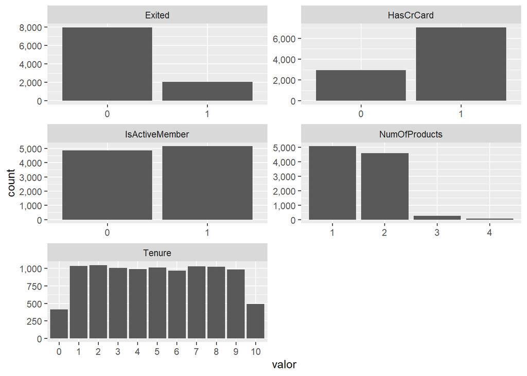

```r
creditos %>%
  select_if(is.factor) %>%
  mutate(id = 1:nrow(.)) %>%
  pivot_longer(-id, names_to = 'variable', values_to = 'valor') %>%
  ggplot(aes(valor)) +
  geom_bar() +
  scale_y_continuous(labels = scales::comma) +
  facet_wrap(~variable, scales = 'free', ncol = 2)
```

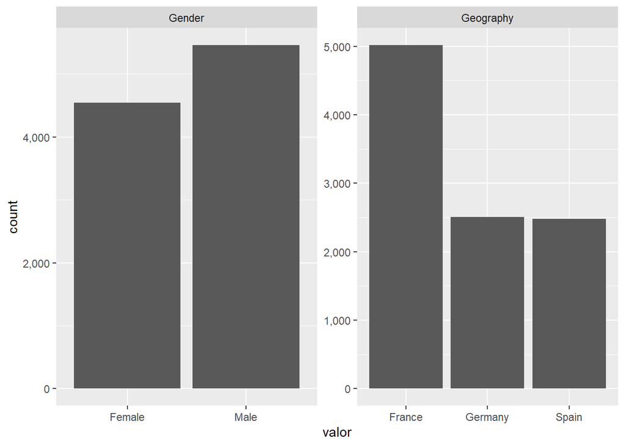

```r
creditos %>%
  select_if(is.character) %>%
  mutate(id = 1:nrow(.)) %>%
  pivot_longer(-id, names_to = 'variable', values_to = 'valor') %>%
  ggplot(aes(valor)) +
  geom_bar() +
  scale_y_continuous(labels = scales::comma) +
  facet_wrap(~variable, scales = 'free', ncol = 2)
```

Las variables categóricas se ven bien, solo la variable NumOfProducts podríamos modificarla para juntar el producto 4 con el producto 3 y nombrar este grupo como “>2”

Ahora, veamos las distribuciones de las variables numéricas con apoyo de unos boxplots y de un resúmen estadístico básico.

Variables numéricas

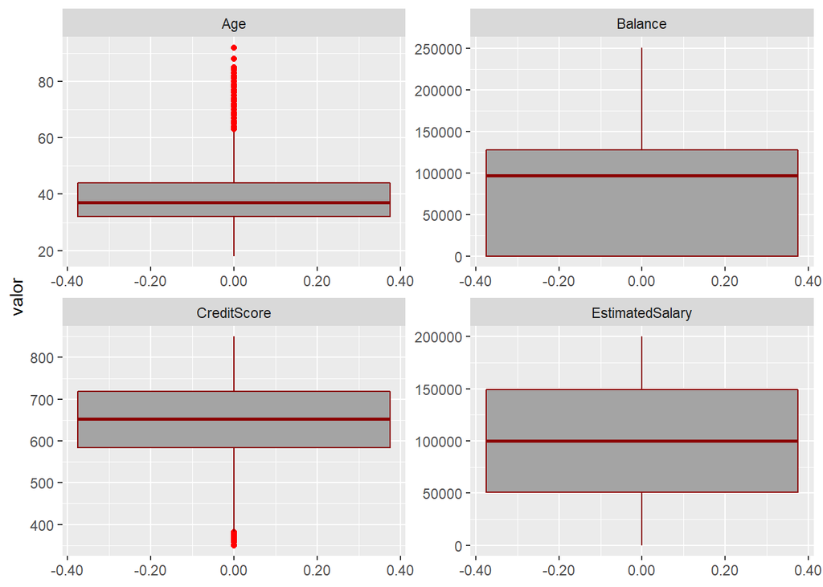

```r
creditos %>%
  select_if(is.numeric) %>%
  mutate(id = 1:nrow(.)) %>%
  pivot_longer(-id, names_to = 'variable', values_to = 'valor') %>%
  ggplot(aes(valor)) +
  geom_boxplot(outlier.colour = "red", fill = '#A4A4A4', color = "darkred") +
  scale_y_continuous(labels = scales::comma) +
  facet_wrap(~variable, scales = 'free', ncol = 2)+
  coord_flip()
```

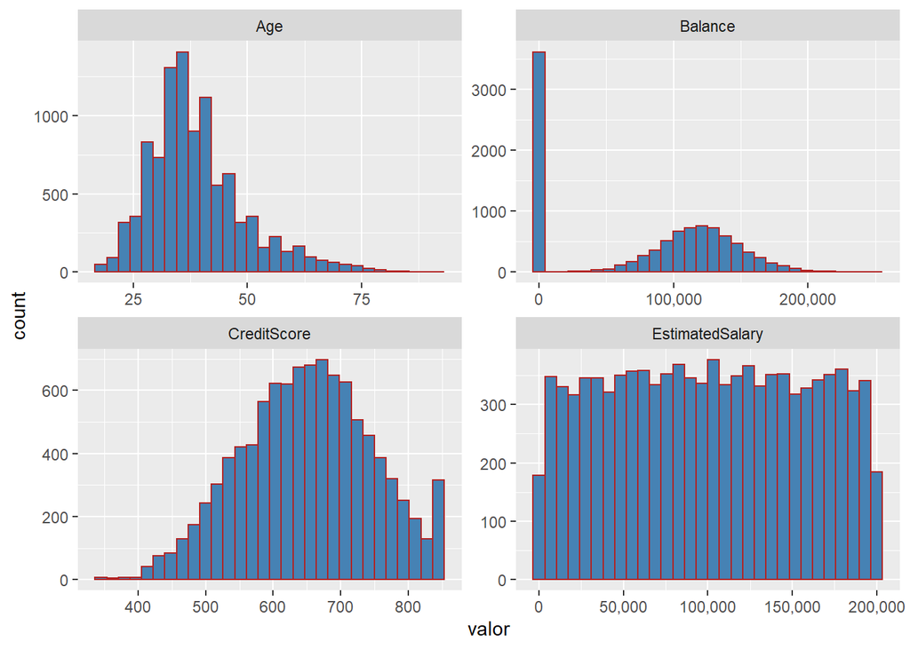

```r
creditos %>%
  select_if(is.numeric) %>%
  mutate(id = 1:nrow(.)) %>%
  pivot_longer(-id, names_to = 'variable', values_to = 'valor') %>%
  ggplot(aes(valor)) +
  geom_histogram(fill = "steelblue", color = "firebrick") +
  scale_x_continuous(labels = scales::comma) +
  facet_wrap(~variable, scales = 'free', ncol = 2)
```

De los gráficos anteriores podemos identificar lo siguiente:

- La variable Age, presenta algunos valores atípicos que parecen corresponder a personas entre los 60 y 92 años.
- En la variable CreditScore, también, hay valores atípicos bajos (menores a 400 pts).
- La variable Balance, quitando el bloque de clientes que no tienen saldo, presenta una distibución normal.
- Finalmente, la variable EstimatedSalary presenta una distribución casi uniforme.

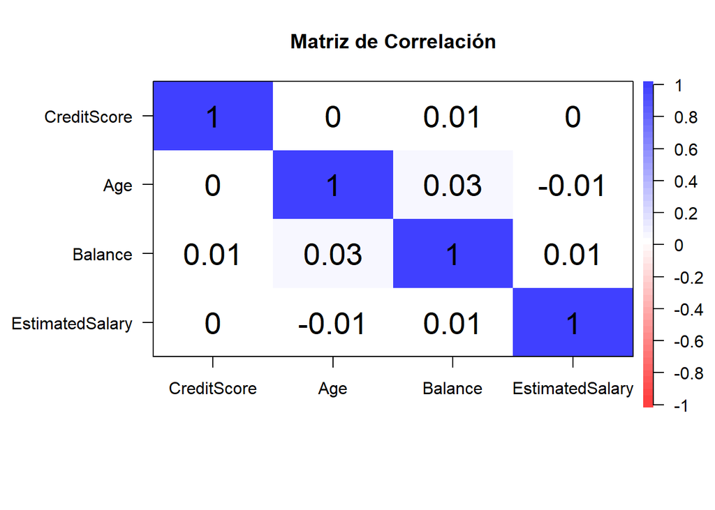

```r
correlacion <- creditos %>%
  select_if(is.numeric) %>%
  cor() %>%
  round(2)

corPlot(correlacion, cex = 1.8, main = "Matriz de Correlación")
```

```r
test.cor <- creditos %>%
  select_if(is.numeric)

findCorrelation(cor(test.cor), cutoff = 0.5, names = TRUE )
```

```
## character(0)
```

La gráfica de matriz muestra que no hay correlaciones altas entre las variables, por lo que, es buena noticia, ya que no tenemos el problema de la multicolinealidad. Lo anterior, también, se comprueba con la función findCorrelation del paquete caret en la cual se pone como umbral un coeficiente de correlación de 0.5 y los resultados muestran que no hay correlaciones que superan ese nivel.

```r
creditos %>%
  select_if(is.numeric) %>%
  describeBy() %>%
  kable(
      format = "html",
      digits = 2,
      size = 5,
      caption = "Resumen Estadístico: variables numéricas",
      format.args = list(big.mark = ","),
      table.attr = "style='width:50%;'") %>%
  kable_styling(bootstrap_options = c("striped", "hover"))
```

Resumen Estadístico: variables numéricas

|  | vars | n | mean | sd | median | trimmed | mad | min | max | range | skew | kurtosis | se |
| --- | --- | --- | --- | --- | --- | --- | --- | --- | --- | --- | --- | --- | --- |
| CreditScore | 1 | 10,000 | 650.53 | 96.65 | 652.00 | 651.01 | 99.33 | 350.00 | 850.0 | 500.0 | -0.07 | -0.43 | 0.97 |
| Age | 2 | 10,000 | 38.92 | 10.49 | 37.00 | 37.91 | 8.90 | 18.00 | 92.0 | 74.0 | 1.01 | 1.39 | 0.10 |
| Balance | 3 | 10,000 | 76,485.89 | 62,397.41 | 97,198.54 | 74,827.80 | 69,336.44 | 0.00 | 250,898.1 | 250,898.1 | -0.14 | -1.49 | 623.97 |
| EstimatedSalary | 4 | 10,000 | 100,090.24 | 57,510.49 | 100,193.91 | 100,114.86 | 72,941.18 | 11.58 | 199,992.5 | 199,980.9 | 0.00 | -1.18 | 575.10 |

A continuación, se crearán algunas gráficas combinando las variables para tener un panorama más completo e integral de los datos, además, esto servirá para ir identificando las posibles variables que pueden ser buenas predictoras.

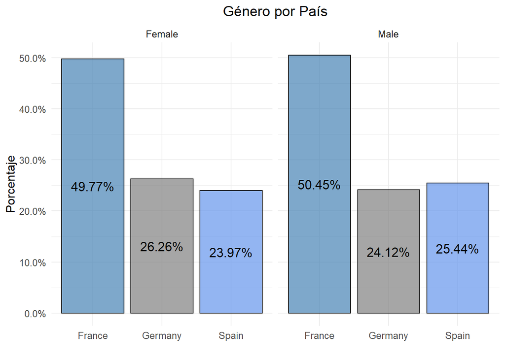

```r
creditos %>%
  ggplot(aes(x = Geography, group = Gender)) +
    geom_bar(aes(y = ..prop.., fill = factor(..x..)),
    stat="count", color = "black", alpha = 0.7) +
  scale_fill_manual(values = c("steelblue", "grey50", "cornflowerblue")) +
    geom_text(aes(label = scales::percent(..prop..),
    y= ..prop.. ), stat= "count", position = position_stack(vjust = 0.5), size = 4.5) +
    facet_grid(~Gender) +
    scale_y_continuous(labels = scales::percent)+
    guides(fill = 'none')+
    labs(title = "Género por País",
    x = "", y = "Porcentaje")+
    theme_minimal()+
    theme(text = element_text(size = 12),
    plot.title = element_text(hjust = 0.5), title = element_text(size = 12))
```

Como se puede ver en el gráfico, la distribución geográfica de clientes para hombres y mujeres es muy similar. Aproximadamente, la misma cantidad de clientes provienen de los 3 países: la mitad proviene de Francia, una cuarta parte proviene de Alemania y otra cuarta parte, de España. Esto es similar tanto para hombres como para mujeres.

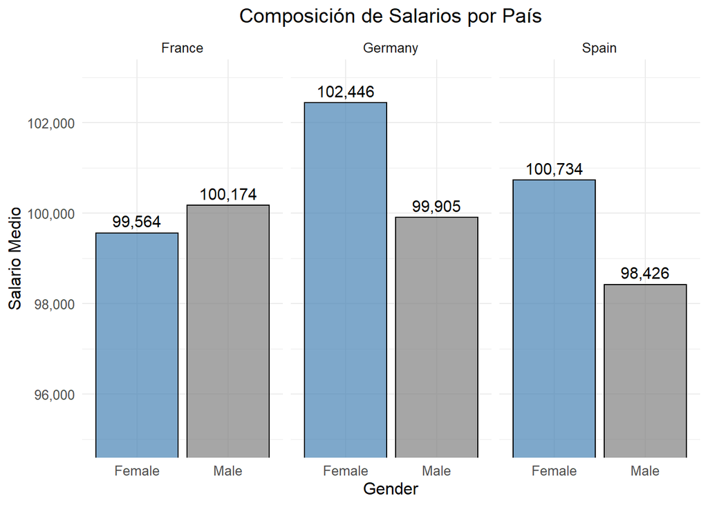

```r
creditos %>%
  group_by(Gender, Geography) %>%
  summarise(media_sal = round(mean(EstimatedSalary), 2)) %>%
  ggplot(aes(x = Gender, y = media_sal, fill = Gender)) +
  scale_fill_manual(values = c("steelblue", "grey50")) +
    geom_bar(stat = "identity", color = "black", alpha = 0.7) +
    geom_text(aes(label = scales::comma(media_sal),
                  vjust = -.5), size = 4) +
    facet_grid(~ Geography) +
    labs(title = "Composición de Salarios por País",
    y = "Salario Medio") +
    theme_minimal() +
    coord_cartesian(ylim = c(95000, 103000)) +
    scale_y_continuous(labels =  scales::comma) +
    guides(fill = 'none') +
    theme(text = element_text(size = 12),
    plot.title = element_text(hjust = 0.5), title = element_text(size = 12))
```

Otro aspecto interesante para explorar es la distribución geográfica de los salarios entre hombres y mujeres. En la gráfica anterior, se observa que el salario promedio en Alemania es mayor que en los otros dos países, siendo el salario promedio de las mujeres el mayor. También hay un mayor salario promedio para las mujeres en España, mientras que en Francia la situación es al revés.

Veamos cuántos clientes han abandonado por zona geográfica y género, para conocer más a profundidad la variable objetivo.

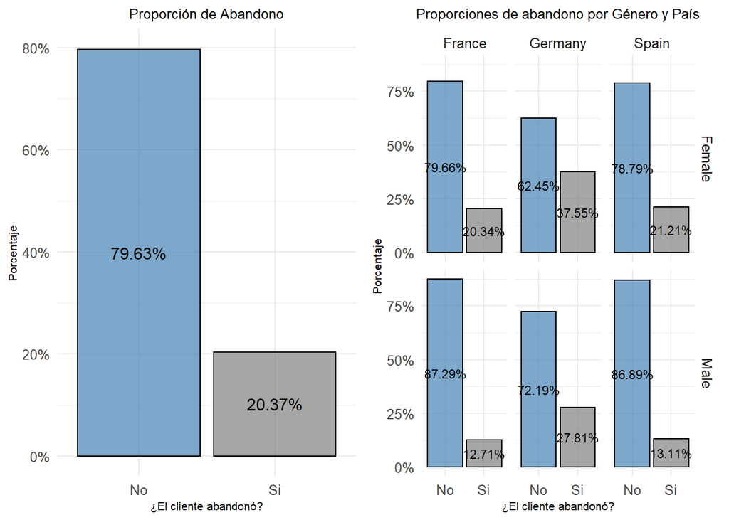

```r
g1 <- ggplot(creditos, aes(x = Exited,
                           y = ..count../sum(..count..), fill = Exited)) +
          geom_bar(color = "black", alpha = 0.7) +
  scale_fill_manual(values = c("steelblue", "grey50")) +
          geom_text(aes(label = paste0(format((..count../sum(..count..))*100,
                                              digits = 4),"%")),
          size = 4, stat= "count", position = position_stack(vjust = 0.5)) +
          scale_y_continuous(labels = percent) +
          labs(title = "Proporción de Abandono", y  = "Porcentaje") +
          scale_x_discrete(name  = "¿El cliente abandonó?",
                          breaks = c("0", "1"),
                          labels = c("No", "Si")) +
          theme_minimal() +
          guides(fill = 'none') +
          theme(text = element_text(size = 12),
          plot.title = element_text(hjust = 0.5), title = element_text(size = 8))

g2 <- ggplot(creditos, aes(x = Exited, group = Gender)) +
    geom_bar(aes(y = ..prop.., fill = factor(..x..)),
    stat="count", color = "black", alpha = 0.7) +
  scale_fill_manual(values = c("steelblue", "grey50")) +
    geom_text(aes(label = scales::percent(..prop..),
    y= ..prop.. ), stat= "count", position = position_stack(vjust = 0.5), size = 3) +
    facet_grid(Gender ~ Geography) +
    scale_y_continuous(labels = scales::percent) +
    scale_x_discrete(name  = "¿El cliente abandonó?",
                          breaks=c("0", "1"),
                          labels=c("No", "Si")) +
    guides(fill = 'none') +
    labs(title = "Proporciones de abandono por Género y País",
         y = "Porcentaje") +
    theme_minimal() +
    theme(text = element_text(size = 12),
    plot.title = element_text(hjust = 0.5), title = element_text(size = 8))

grid.arrange(g1, g2, ncol = 2)
```

En las gráficas anteriores podemos ver la información más importante sobre las tasas de abandono entre los clientes. Se puede decir que uno de cada cinco clientes abandonó la institución. Además, se puede observar que las tasas de abandono en Alemania son las más altas entre los demás países, lo anterior, también se ve reflejado tanto para hombres como para mujeres. La menor cantidad de abandono se localiza en Francia, mientras que España ocupa una posición intermedia.

Además, algo importante a considerar es que los datos estan desbalanceados, por lo que, debemos tenerlo presente a la hora de construir los modelos.

Tratemos de identificar, en promedio, el tiempo en el que los clientes abandonan el banco.

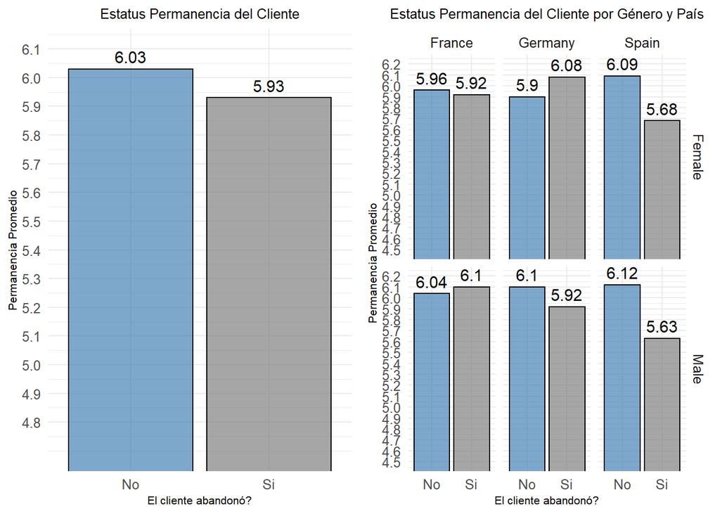

```r
creditos.t <- creditos
creditos.t$Tenure <- as.double(creditos.t$Tenure)

duracion <- creditos.t %>%
  group_by(Exited) %>%
  summarise(tiempo.promedio = round(mean(Tenure), 2))

g3 <- ggplot(duracion, aes(x = Exited, y = tiempo.promedio, fill = Exited)) +
    geom_bar(stat = "identity", color = "black", alpha = 0.7) +
    geom_text(aes(label = tiempo.promedio, vjust = -.5), size = 4) +
    scale_x_discrete(name  = "El cliente abandonó?",
                          breaks = c("0", "1"),
                          labels = c("No", "Si")) +
    theme_minimal() +
  scale_fill_manual(values = c("steelblue", "grey50")) +
    coord_cartesian(ylim = c(4.7, 6.1)) +
    scale_y_continuous(breaks = seq(4.8, 6.1, 0.1)) +
    guides(fill = 'none') +
    theme(text = element_text(size = 12),
          plot.title = element_text(hjust = 0.5), title = element_text(size = 8)) +
    labs(title = "Estatus Permanencia del Cliente",
         y = "Permanencia Promedio")


duracion2 <- creditos.t %>%
  group_by(Exited, Gender, Geography) %>%
  summarise(tiempo.promedio = round(mean(Tenure), 2))

g4 <- ggplot(duracion2,
             aes(x = Exited, y = tiempo.promedio, group = Gender, fill = Exited)) +
    geom_bar(stat = "identity", color = "black", alpha = 0.7) +
    geom_text(aes(label = tiempo.promedio, vjust = -.5), size = 4) +
    scale_x_discrete(name  = "El cliente abandonó?",
                          breaks = c("0", "1"),
                          labels = c("No", "Si"))+
    facet_grid(Gender ~ Geography) +
    theme_minimal() +
    scale_fill_manual(values = c("steelblue", "grey50")) +
    coord_cartesian(ylim=c(4.5, 6.2)) +
    scale_y_continuous(breaks = seq(4.5, 6.2, 0.1)) +
    guides(fill = 'none')+
    theme(text = element_text(size = 12),
          plot.title = element_text(hjust = 0.5), title = element_text(size = 8)) +
    labs(title = "Estatus Permanencia del Cliente por Género y País",
         y = "Permanencia Promedio")

grid.arrange(g3, g4, ncol = 2)
```

En las gráficas de permanencia podemos destacar lo siguiente:

- El tiempo promedio de permanencia entre los clientes que abandonan el banco y los que permanecen son muy parecidos.
- España tiene los promedios más bajos de abandono tanto en hombres como para mujeres.
- Alemania presenta el promedio más alto de abandono en el grupo de las mujeres y Francia en el grupo de los hombres.

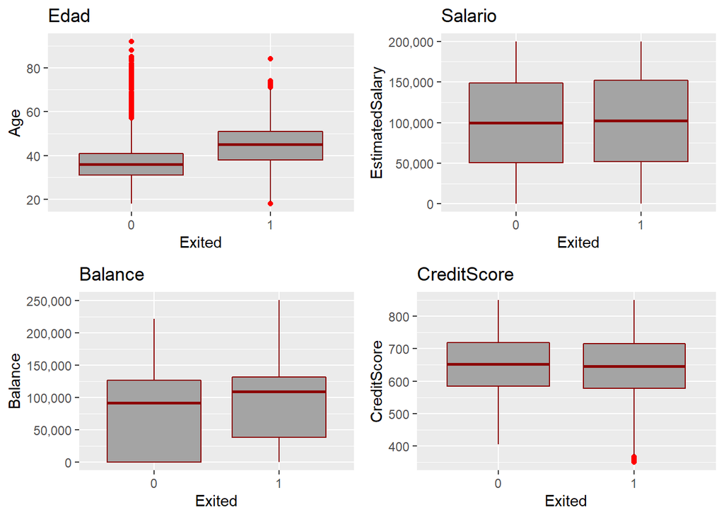

```r
g5 <- creditos %>%
  ggplot(aes(x = Exited, y = Age)) +
  geom_boxplot(outlier.color = "red", fill = '#A4A4A4', color = "darkred") +
  labs(
    title = "Edad"
  )

g6 <- creditos %>%
  ggplot(aes(x = Exited, y = EstimatedSalary)) +
  geom_boxplot(outlier.color = "red", fill = '#A4A4A4', color = "darkred") +
  scale_y_continuous(labels = scales::comma) +
  labs(
    title = "Salario"
  )

g7 <- creditos %>%
  ggplot(aes(x = Exited, y = Balance)) +
  geom_boxplot(outlier.color = "red", fill = '#A4A4A4', color = "darkred") +
  scale_y_continuous(labels = scales::comma) +
  labs(
    title = "Balance"
  )

g8 <- creditos %>%
  ggplot(aes(x = Exited, y = CreditScore)) +
  geom_boxplot(outlier.color = "red", fill = '#A4A4A4', color = "darkred") +
  labs(
    title = "CreditScore"
  )

grid.arrange(g5, g6, g7, g8, ncol = 2)
```

# Pre procesamiento de los datos

El preprocesamiento de datos es el proceso de convertir datos sin procesar o “crudos” en un formato legible que es adecuado para construir y entrenar modelos de aprendizaje automático.

## Selección de variables

Casi al inicio del proyecto se empezó a realizar la selección de variables cuando se eliminaron las columnas ‘RowNumber’, ‘CustomerId’ y ‘Surname’. En la sección del análisis exploratorio identificamos varias características más que pueden descartarse ya que no proporcionan ningún valor para predecir nuestra variable objetivo: Exited.

- La variable EstimatedSalary muestra una distribución casi uniforme para ambos tipos de clientes, por lo que, se puede descartar.
- Las categorías de ‘Tenure’ y ‘HasCrCard’ tienen una tasa de abandono similar (alrededor de 20%) y se consideran redundantes. Esto se puede confirmar con una prueba de chi-cuadrado:

```r
creditos %>%
  tabyl(Tenure, Exited, show_missing_levels = FALSE) %>%
  adorn_totals("row") %>%
  adorn_percentages("all") %>%
  adorn_pct_formatting(digits = 1) %>%
  adorn_ns %>%
  adorn_title
```

|  | Exited |  |
| --- | --- | --- |
| Tenure | 0 | 1 |
| 0 | 3.2% (318) | 0.9% (95) |
| 1 | 8.0% (803) | 2.3% (232) |
| 2 | 8.5% (847) | 2.0% (201) |
| 3 | 8.0% (796) | 2.1% (213) |
| 4 | 7.9% (786) | 2.0% (203) |
| 5 | 8.0% (803) | 2.1% (209) |
| 6 | 7.7% (771) | 2.0% (196) |
| 7 | 8.5% (851) | 1.8% (177) |
| 8 | 8.3% (828) | 2.0% (197) |

[output cut: 3 more lines]

```r
creditos %>%
  tabyl(HasCrCard, Exited, show_missing_levels = FALSE) %>%
  adorn_totals("row") %>%
  adorn_percentages("all") %>%
  adorn_pct_formatting(digits = 1) %>%
  adorn_ns %>%
  adorn_title
```

|  | Exited |  |
| --- | --- | --- |
| HasCrCard | 0 | 1 |
| 0 | 23.3% (2332) | 6.1% (613) |
| 1 | 56.3% (5631) | 14.2% (1424) |
| Total | 79.6% (7963) | 20.4% (2037) |

```r
t <- creditos %>%
  select_if(is.factor)

categorias <- t %>%
  dplyr::select(-Exited) %>%
  names()

chi <- vector()
p.value <- vector()

for (columna in categorias){

  test <- stats::chisq.test(t[columna], t$Exited)

  chi <- append(chi, test[["statistic"]][["X-squared"]])
  p.value <- append(p.value, test[["p.value"]])

  }

df.chi <- data.frame(categorias, chi, p.value) %>%
  arrange(desc(-p.value))

df.chi %>%
  kable(caption = "Prueba Chi-cuadrada", align = "c") %>%
  kable_styling(bootstrap_options = c("striped", "hover"))
```

Prueba Chi-cuadrada

| categorias | chi | p.value |
| --- | --- | --- |
| NumOfProducts | 1503.6293615 | 0.0000000 |
| IsActiveMember | 242.9853416 | 0.0000000 |
| Tenure | 13.9003726 | 0.1775846 |
| HasCrCard | 0.4713378 | 0.4923724 |

Las variables Tenure y HasCrCard tienen un chi-cuadrado pequeño y un p-valor mayor que 0.05 (nivel de significancia estándar), lo que confirma la conclusión anterior de que estas dos características no transmiten ninguna información útil. Por lo tanto, se recomienda eliminarlas del análisis, sin embargo, para poder tomar esa decisión con mayor certeza, se identificará la importancia que tiene cada variable.

Importancia de las variables

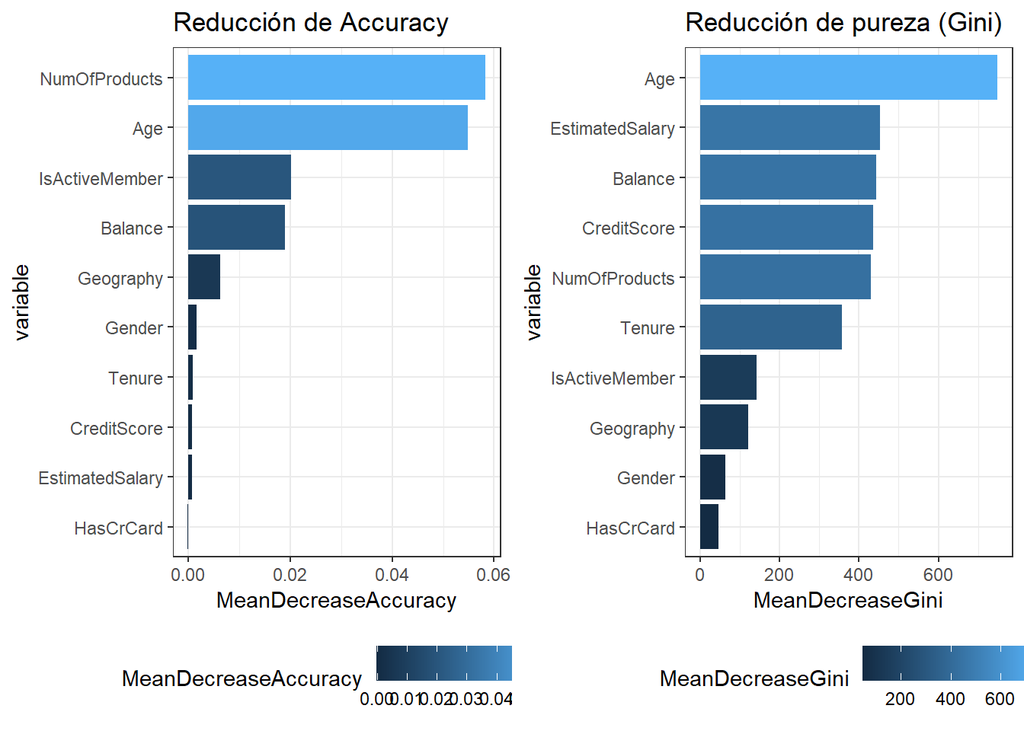

```r
creditos.rf <- map_if(.x = creditos, .p = is.character, .f = as.factor) %>%
  as.data.frame()

modelo.importancia <- randomForest(formula = Exited ~ . ,
                                   data = na.omit(creditos),
                                   mtry = 5,
                                   importance = TRUE,
                                   ntree = 1000)

importancia <- as.data.frame(modelo.importancia$importance)
importancia <- rownames_to_column(importancia, var = "variable")

g9 <- ggplot(data = importancia,
             aes(x = reorder(variable, MeanDecreaseAccuracy),
                 y = MeanDecreaseAccuracy, fill = MeanDecreaseAccuracy)) +
  labs(x = "variable",
       title = "Reducción de Accuracy") +
  geom_col() +
  coord_flip() +
  theme_bw() +
  theme(legend.position = "bottom")

g10 <- ggplot(data = importancia,
              aes(x = reorder(variable, MeanDecreaseGini),
                  y = MeanDecreaseGini, fill = MeanDecreaseGini)) +
  labs(x = "variable", title = "Reducción de pureza (Gini)") +
  geom_col() +
  coord_flip() +
  theme_bw() +
  theme(legend.position = "bottom")

ggarrange(g9, g10)
```

En ambas gráficas, la variable HasCrcard tiene muy poca influencia sobre la variable objetivo. La variable Tenure parece que puede aportar algo al modelo, sin embargo, como se vio, anteriormente, dicha variable presenta una distribución uniforme, por lo que, no será un buen predictor. Lo mismo pasa con la variable EstimatedSalary.

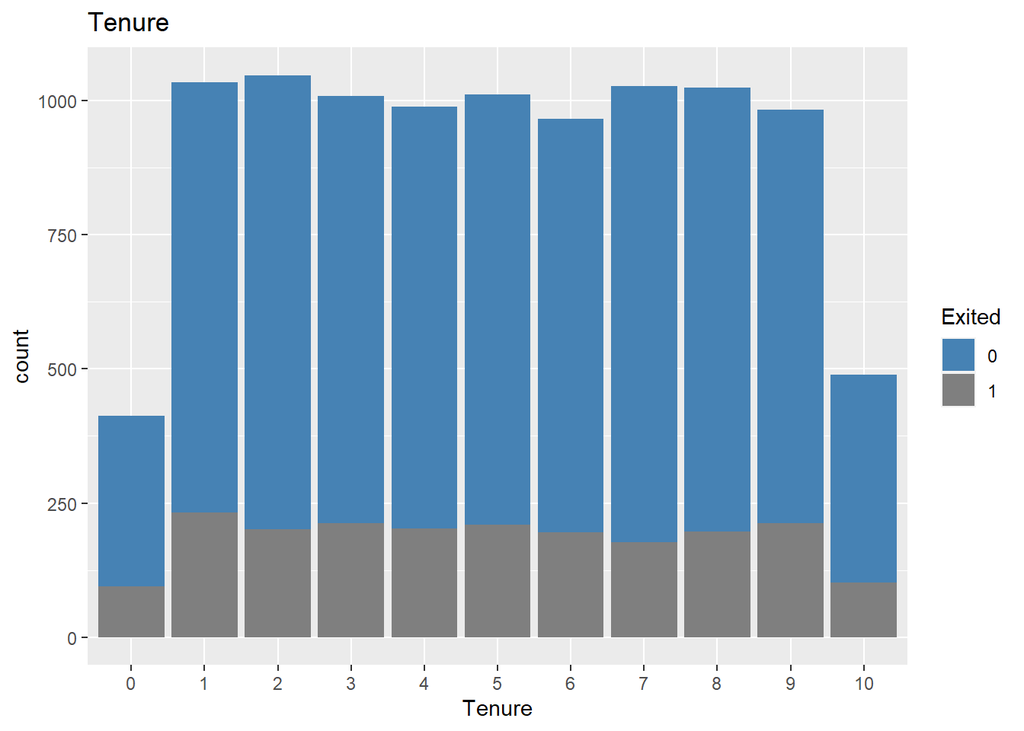

```r
creditos %>%
  ggplot(aes(x = Tenure, y = ..count.., fill = Exited)) +
  geom_bar() +
  scale_fill_manual(values = c("steelblue", "gray50")) +
  labs(title = "Tenure")
```

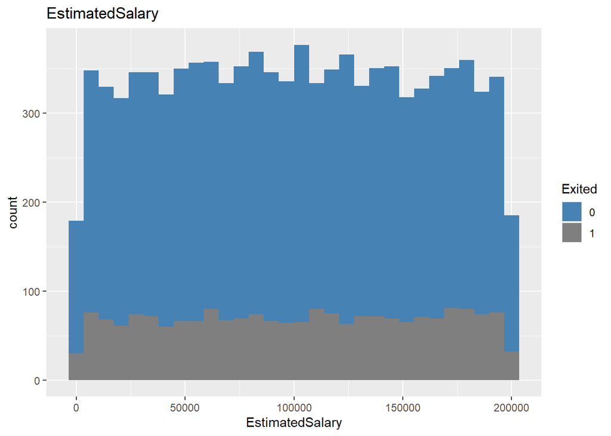

```r
creditos %>%
  ggplot(aes(x = EstimatedSalary, y = ..count.., fill = Exited)) +
  geom_histogram() +
  scale_fill_manual(values = c("steelblue", "gray50")) +
  labs(title = "EstimatedSalary")
```

En las gráficas, ambas variables no muestran ser diferenciadoras o influyentes para determinar si un cliente se queda o abandona el banco, además, esto ya se había sospechado al ver los boxplots. Por tanto se eliminan.

```r
creditos <- creditos %>%
  dplyr::select(-c(Tenure, HasCrCard, EstimatedSalary))
```

## Codificación de variables categóricas

La mayoría de los algoritmos de machine learning, generalmente, requieren que todas las características de entrada (y salida) sean numéricas. Por lo que, las variables categóricas deben convertirse (codificarse) en números antes de construir los modelos.

Hasta el aquí, el conjunto de datos contiene dos características que requieren codificación: Gender y Geography.

```r
creditos$Gender <- ifelse(creditos$Gender == 'Female', 0, 1)
creditos$Gender <- as.factor(creditos$Gender)

creditos$Geography <- ifelse(creditos$Geography == 'France' | creditos$Geography =='Spain',
                             0, 1)

creditos$Geography <- as.factor(creditos$Geography)

creditos <- creditos %>%
  mutate(NumOfProducts = fct_collapse(NumOfProducts,
                                      '1' = '1',
                                      '2' = '2',
                                      other_level = '>2'))
```

## Escalamiento

El escalado de características es una técnica que se utiliza para normalizar el rango de variables en un conjunto de datos cuando éstas tienen diferentes magnitudes, por ejemplo, no es la misma diferencia entre el rango de la edad y el rango del Balance. Para que las variables con magnitudes grandes no dominen el resto de los datos se deben escalar todas las variables. Algunos algoritmos son sensibles a la escala de características (por ejemplo, SVM), mientras que otros son invariantes (por ejemplo, bosques aleatorios).

```r
s <- c("Age", "Balance", "CreditScore")

creditos[s] <- scale(creditos[s])
```

## Balanceo de clases

Como hemos visto anteriormente, existe un desbalanceo en las clases de la variable objetivo, con una clase (0 = no abandono) mucho más prevalente que la otra (1 = abandono):

```r
table(creditos$Exited)
```

```
##
##    0    1
## 7963 2037
```

Antes de seguir adelante, por conveniencia, vamos a recodificar la variable Exited para que las clases queden de la siguiente manera:

- clase positiva: **churn (abandona)**
- clase negativa: **stay (permanece)**

```r
creditos$Exited <- ifelse(creditos$Exited == '1', 'churn', 'stay')
creditos$Exited <- as.factor(creditos$Exited)

table(creditos$Exited)
```

```
##
## churn  stay
##  2037  7963
```

El desbalanceo de clases suele ser un problema frecuente sobre todo en modelos de abandono de clientes o en temas de riesgo o fraudes. La clasificación que utiliza datos desequilibrados está sesgada a favor de la clase mayoritaria, lo que significa que los algoritmos de machine learning probablemente darán como resultado modelos que hacen poco más que predecir la clase más común. Además, las métricas comunes pueden ser engañosas cuando se manejan datos con desequilibrio de clases (por ejemplo, si un conjunto de datos contiene 99,9% de la clase “0” y 0,01% de la clase “1”, un clasificador que siempre predice “0” tendrá una precisión del 99,9%). Además, dan lugar a predicciones sesgadas.

Existen algunas estrategias que pueden abordar este problema como, por ejemplo, el submuestreo, sobremuestreo, generación de datos sintéticos, etc. Sin embargo, antes de continuar dividiremos el conjunto de datos en una parte de entrenamiento, validación y prueba, para evitar caer en un sobreajuste en el desempeño de los modelos. Las divisiones serán: 70%-15%-15%, respectivamente.

**Entrenamiento:**

Es el conjunto de datos que se utiliza para entrenar y hacer que el modelo aprenda las características / patrones ocultos en los datos.

**Validación:**

El conjunto de validación es un conjunto de datos separado del conjunto de entrenamiento, que se utiliza para validar el rendimiento de nuestro modelo durante el entrenamiento.

**Prueba:**

El conjunto de prueba es un conjunto separado de datos utilizados para probar el modelo después de completar el entrenamiento. Son observaciones que el algoritmo no ha visto.

```r
set.seed(123)

div1 <- createDataPartition(y = creditos$Exited,
                                      p = 0.7,
                                      list = FALSE,
                                      times = 1)

creditos.train <- creditos[div1,] # entrenamiento
creditos2 <- creditos[-div1,]


div2 <- createDataPartition(y = creditos2$Exited,
                                      p = 0.5,
                                      list = FALSE,
                                      times = 1)


creditos.validacion <- creditos2[div2,] # validacion
creditos.test <- creditos2[-div2,] # prueba
```

Solo verificamos la distribución original de las clases en los tres conjuntos de datos:

```r
# train
prop.table(table(creditos.train$Exited))
```

```
##
##     churn      stay
## 0.2036852 0.7963148
```

```r
nrow(creditos.train)
```

```
## [1] 7001
```

```r
# validacion
prop.table(table(creditos.validacion$Exited))
```

```
##
## churn  stay
## 0.204 0.796
```

```r
nrow(creditos.validacion)
```

```
## [1] 1500
```

```r
# test
prop.table(table(creditos.test$Exited))
```

```
##
##    churn     stay
## 0.203469 0.796531
```

```r
nrow(creditos.test)
```

```
## [1] 1499
```

```r
set.seed(123)

creditos.bal <- ROSE(Exited ~ .,
                  data = creditos.train,
                  seed = 1)$data

table(creditos.bal$Exited)
```

```
##
##  stay churn
##  3516  3485
```

```r
prop.table(table(creditos.bal$Exited))
```

```
##
##     stay    churn
## 0.502214 0.497786
```

# Métrica de evaluación

Es indispensable definir, en los modelos de aprendizaje supervisado, una métrica que sirva para evaluar la capacidad predictiva del modelo final, ademas, servirá para ir comparando los modelos generados así como su calibración.

Como este proyecto aborda un problema de clasificación, ya que la variable a predecir es categórica, y lo que se pretende es que el modelo clasifique correctamente las observaciones de la clase positiva, es decir, los clientes que abandonan, por ser más crítico para el banco, la métrica de evaluación elegida será la **Sensibilidad o Recall**, porque esta métrica representa la fracción de verdaderos positivos, para tenerlos bien identificados y dirigir campañas de fidelización con el objetivo de que no se vayan. En otras palabras, queremos evitar clasificar a un cliente que abandona el banco en la clase de los que permaneceran.

La fórmula es:

**Sensitivity = VP/(VP + FN)**

VP: Verdaderos positivos

FN: Falsos negativos

# Creación de modelos de aprendizaje automático

Siempre que se va a hacer un modelo de machine learning y en específico un modelo de aprendizaje supervisado es altamente recomendable iniciar creando un modelo base a partir del cual se tratará de mejorar los resultados ya sea calibrando sus hiperparámetros (si los tiene) o creando otros algoritmos.

Para tener una medida de referencia y sobre la cual mejorar esos resultados, se creará un modelo que será: Naive Bayes.

## Modelo base: Naive Bayes

Como se va a utilizar el paquete **caret**, por conveniencia vamos a crear el objeto recipe, para poder ejecutar los algoritmos:

```r
# Se crea un objeto recipe
objeto.recipe <- recipe(formula = Exited ~ CreditScore + Geography + Gender + Age +
                          Balance + NumOfProducts + IsActiveMember,
                        data = creditos.bal)

objeto.recipe
```

```
## Recipe
##
## Inputs:
##
##       role #variables
##    outcome          1
##  predictor          7
```

```r
# Se entrena el objeto recipe
trained.recipe <- prep(objeto.recipe, training = creditos.bal)

trained.recipe
```

```
## Recipe
##
## Inputs:
##
##       role #variables
##    outcome          1
##  predictor          7
##
## Training data contained 7001 data points and no missing data.
```

```r
# Se preparan los objetos
creditos.train.prep <- bake(trained.recipe, new_data = creditos.bal)
creditos.validacion.prep <- bake(trained.recipe, new_data = creditos.validacion)
creditos.test.prep <- bake(trained.recipe, new_data = creditos.test)

glimpse(creditos.train.prep)
```

```
## Rows: 7,001
## Columns: 8
## $ CreditScore    <dbl> 0.476236104, -0.327942574, -0.110973502, 0.409201095, 0~
## $ Geography      <fct> 1, 0, 0, 1, 0, 1, 0, 1, 0, 0, 0, 0, 0, 1, 0, 1, 0, 1, 0~
## $ Gender         <fct> 1, 1, 1, 0, 0, 1, 1, 0, 1, 1, 1, 1, 1, 1, 0, 1, 1, 0, 1~
## $ Age            <dbl> 2.349714505, 0.005396935, 0.113704231, -1.119619671, -1~
## $ Balance        <dbl> 0.65916998, -1.05626772, -1.26977342, 0.05753502, 0.436~
## $ NumOfProducts  <fct> 1, 2, 1, 2, 1, 1, 1, 2, 1, 2, 1, 2, 2, 2, 1, 2, 1, 1, 1~
## $ IsActiveMember <fct> 1, 1, 0, 0, 0, 1, 1, 1, 0, 1, 0, 0, 1, 1, 1, 0, 0, 0, 1~
## $ Exited         <fct> stay, stay, stay, stay, stay, stay, stay, stay, stay, s~
```

```r
glimpse(creditos.validacion.prep)
```

```
## Rows: 1,500
## Columns: 8
## $ CreditScore    <dbl> -0.35724389, -0.61590034, -1.00905816, -1.84710509, -0.~
## $ Geography      <fct> 1, 0, 1, 0, 0, 1, 1, 0, 1, 0, 0, 0, 0, 0, 0, 1, 0, 1, 0~
## $ Gender         <fct> 1, 0, 1, 1, 0, 0, 1, 1, 0, 1, 0, 1, 1, 1, 0, 0, 1, 1, 1~
## $ Age            <dbl> 0.579549215, 0.007456278, 0.198153924, 0.102805101, 2.1~
## $ Balance        <dbl> 1.0680496, -1.2257864, 0.5389110, -1.2257864, 0.6560122~
## $ NumOfProducts  <fct> 2, >2, 2, 1, 1, 2, 2, 1, 2, 1, 2, 2, 2, 2, 1, 1, 1, 2, ~
## $ IsActiveMember <fct> 1, 0, 0, 0, 1, 0, 0, 0, 0, 0, 1, 1, 1, 0, 1, 1, 0, 0, 0~
## $ Exited         <fct> stay, churn, stay, stay, stay, stay, stay, stay, stay, ~
```

```r
glimpse(creditos.test.prep)
```

```
## Rows: 1,499
## Columns: 8
## $ CreditScore    <dbl> -0.05720239, 0.34630168, -1.05044320, -0.65728538, 2.02~
## $ Geography      <fct> 0, 0, 0, 0, 0, 0, 0, 1, 0, 1, 0, 1, 0, 1, 0, 0, 1, 1, 1~
## $ Gender         <fct> 1, 1, 0, 1, 0, 1, 1, 1, 1, 1, 0, 1, 1, 1, 1, 0, 1, 1, 0~
## $ Age            <dbl> 0.48420039, -1.13672960, -1.32742724, 0.57954922, -0.08~
## $ Balance        <dbl> 0.597298727, 0.931416788, -1.225786377, -1.225786377, -~
## $ NumOfProducts  <fct> 2, 1, 2, 1, 1, 2, 1, 1, 1, 1, 1, 1, 2, 1, 2, 2, 1, 1, 1~
## $ IsActiveMember <fct> 0, 1, 0, 0, 1, 1, 1, 1, 1, 0, 0, 0, 0, 1, 0, 1, 1, 0, 0~
## $ Exited         <fct> churn, stay, stay, stay, stay, stay, stay, stay, stay, ~
```

Naive Bayes

```r
# paralelizacion del proceso
cores <- detectCores()-1
cl <- makeCluster(cores, type = "SOCK")
registerDoSNOW(cl)

# hiperparametros, no. repeticiones y semilla para cada repeticion
particiones <- 10
repeticiones <- 5

hiperparametros <- data.frame(usekernel = FALSE, fL = 0 , adjust = 0)

set.seed(123)

seeds <- vector(mode = "list", length = (particiones * repeticiones) + 1)

for (i in 1:(particiones * repeticiones)) {
  seeds[[i]] <- sample.int(1000, nrow(hiperparametros))
  }

seeds[[(particiones * repeticiones) + 1]] <- sample.int(1000, 1)

# definicion del entrenamiento
control.train <- trainControl(method = "repeatedcv",
                              number = particiones,
                              repeats = repeticiones,
                              seeds = seeds,
                              returnResamp = "final",
                              verboseIter = FALSE,
                              allowParallel = TRUE)

# ajuste del modelo
set.seed(342)

modelo_nb <- train(Exited ~ .,
                   data = creditos.train.prep[-6],
                   method = "nb",
                   tuneGrid = hiperparametros,
                   metric = "Accuracy",
                   trControl = control.train)

# se guarda el modelo
saveRDS(modelo_nb, file = "modelo.nb.rds")
```

```r
modelo_nb <- readRDS(file = "Modelos_2/modelo.nb.rds")
```

El Accuracy en el conjunto de entrenamiento del modelo Naive Bayes final fue de: **69.6130112%**

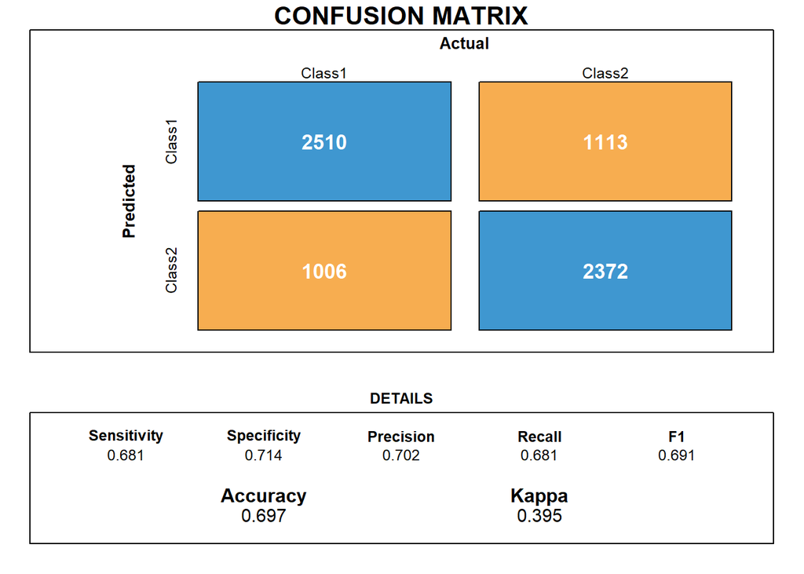

```r
cm.nb <- confusionMatrix(predict(modelo_nb), creditos.train.prep$Exited, positive = "churn")

draw_confusion_matrix(cm.nb)
```

La Sensitivity en el set de train fue de: **68.0631277%**

Ahora estamos listos para comenzar a construir modelos de aprendizaje automático. Los algoritmos clasificadores que se han seleccionado son los siguientes:

- Logistic Regression (LOGIT)
- Support Vector Machine (SVM)
- Random Forest (RF)
- Extreme Gradient Boosting (XGBoost)
- Neuronal Network (NNET)
- Gradient Boosting Machine (GBM)

Regresión Logística

```r
# paralelizacion del proceso
cores <- detectCores()-1
cl <- makeCluster(cores, type = "SOCK")
registerDoSNOW(cl)

# hiperparametros, no. repeticiones y semilla para cada repeticion
particiones <- 10
repeticiones <- 5

hiperparametros <- data.frame(parameter = "none")

set.seed(123)

seeds <- vector(mode = "list", length = (particiones * repeticiones) + 1)

for (i in 1:(particiones * repeticiones)) {
  seeds[[i]] <- sample.int(1000, nrow(hiperparametros))
  }

seeds[[(particiones * repeticiones) + 1]] <- sample.int(1000, 1)

# definicion del entrenamiento
control.train <- trainControl(method = "repeatedcv",
                              number = particiones,
                              repeats = repeticiones,
                              seeds = seeds,
                              returnResamp = "final",
                              verboseIter = FALSE,
                              allowParallel = TRUE)

# ajuste del modelo
set.seed(342)

modelo_logistic <- train(Exited ~ .,
                   data = creditos.train.prep,
                   method = "glm",
                   tuneGrid = hiperparametros,
                   metric = "Accuracy",
                   trControl = control.train,
                   family = "binomial")

# se guarda el modelo
saveRDS(modelo_logistic, file = "modelo.logit.rds")
```

```r
modelo_logistic <- readRDS(file = "Modelos_2/modelo.logit.rds")
```

El Accuracy en el conjunto de entrenamiento del modelo hecho con la Regresión Logística fue de: **75.7865582%**

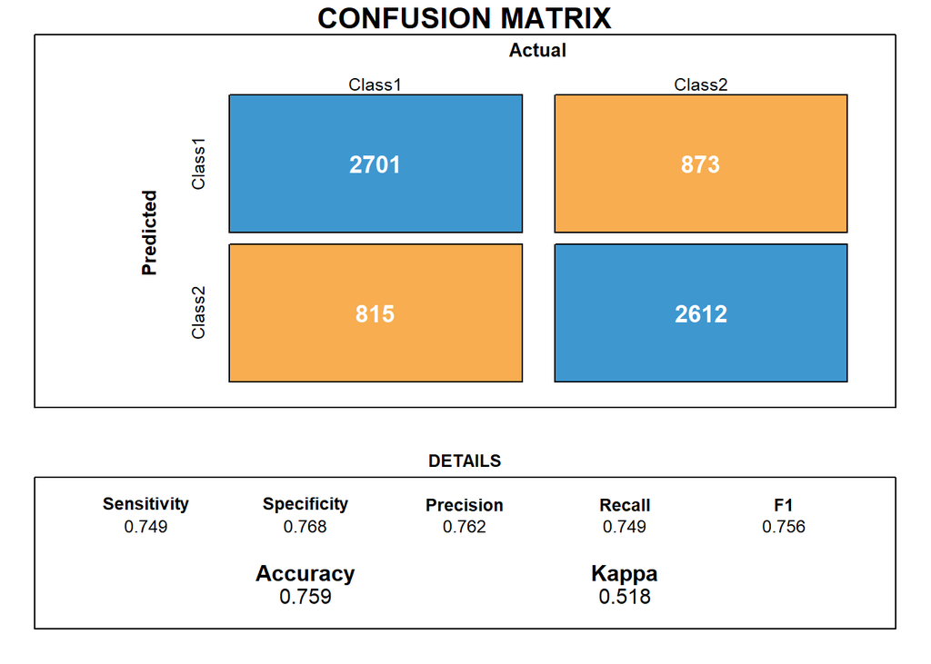

```r
cm.lg <- confusionMatrix(predict(modelo_logistic), creditos.train.prep$Exited, positive = "churn")

draw_confusion_matrix(cm.lg)
```

La Sensitivity en el set de train fue de: **74.9497848%**

Máquinas de Vector Soporte

```r
# paralelizacion del proceso
cores <- detectCores()-1
cl <- makeCluster(cores, type = "SOCK")
registerDoSNOW(cl)

# hiperparametros, no. repeticiones y semilla para cada repeticion
particiones <- 10
repeticiones <- 5

hiperparametros <- expand.grid(sigma = c(0.001, 0.01, 0.1, 0.5, 1),
                               C = c(1 , 20, 50, 100, 200, 500, 700))

set.seed(123)

seeds <- vector(mode = "list", length = (particiones * repeticiones) + 1)

for (i in 1:(particiones * repeticiones)) {
  seeds[[i]] <- sample.int(1000, nrow(hiperparametros))
  }

seeds[[(particiones * repeticiones) + 1]] <- sample.int(1000, 1)

# definicion del entrenamiento
control.train <- trainControl(method = "repeatedcv",
                              number = particiones,
                              repeats = repeticiones,
                              seeds = seeds,
                              returnResamp = "final",
                              verboseIter = FALSE,
                              allowParallel = TRUE)

# ajuste del modelo
set.seed(342)

modelo_svm <- train(Exited ~ .,
                   data = creditos.train.prep,
                   method = "svmRadial",
                   tuneGrid = hiperparametros,
                   metric = "Accuracy",
                   trControl = control.train)

# se guarda el modelo
saveRDS(modelo_svm, file = "modelo.svm.rds")
```

```r
modelo_svm <- readRDS(file = "Modelos_2/modelo.svm.rds")
```

El accuracy promedio del modelo Support Vector Machine en el conjunto de entrenamiento fue de: **77.3878016%**

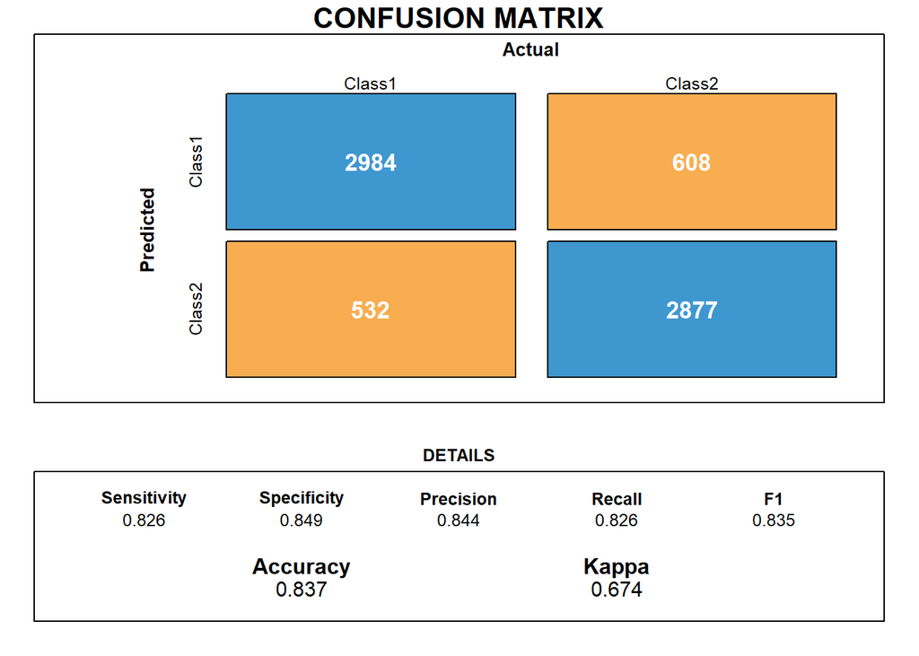

```r
cm.svm <- confusionMatrix(predict(modelo_svm), creditos.train.prep$Exited, positive = "churn")

draw_confusion_matrix(cm.svm)
```

La Sensitivity en el set de train fue de: **82.553802%**

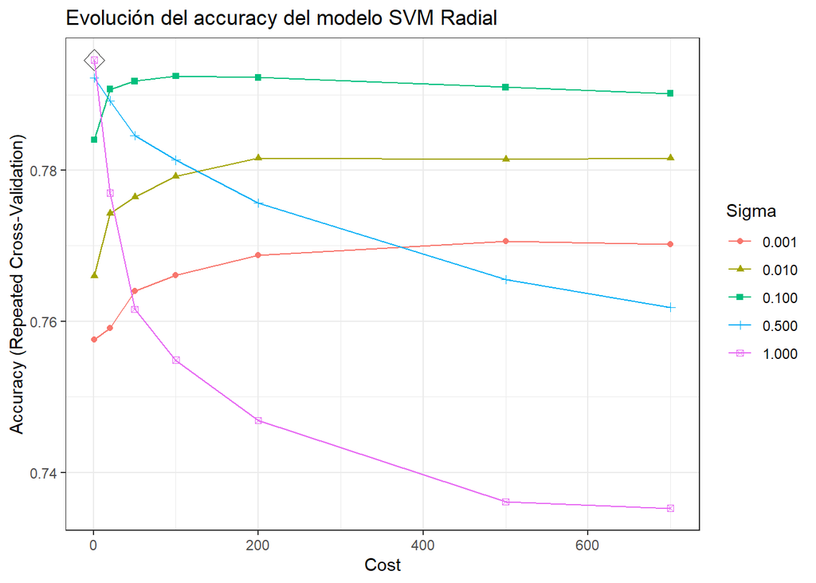

```r
# representacion gráfica
ggplot(modelo_svm, highlight = TRUE) +
  labs(title = "Evolución del accuracy del modelo SVM Radial") +
  theme_bw()
```

Random Forest

```r
# paralelizacion del proceso
cores <- detectCores()-1
cl <- makeCluster(cores, type = "SOCK")
registerDoSNOW(cl)

# hiperparametros, no. repeticiones y semilla para cada repeticion
particiones <- 10
repeticiones <- 5

hiperparametros <- expand.grid(mtry = c(3, 4, 5, 7),
                               min.node.size = c(2, 3, 4, 5, 10, 15, 20, 30),
                               splitrule = "gini")

set.seed(123)

seeds <- vector(mode = "list", length = (particiones * repeticiones) + 1)

for (i in 1:(particiones * repeticiones)) {
  seeds[[i]] <- sample.int(1000, nrow(hiperparametros))
  }

seeds[[(particiones * repeticiones) + 1]] <- sample.int(1000, 1)

# definicion del entrenamiento
control.train <- trainControl(method = "repeatedcv",
                              number = particiones,
                              repeats = repeticiones,
                              seeds = seeds,
                              returnResamp = "final",
                              verboseIter = FALSE,
                              allowParallel = TRUE)

# ajuste del modelo
set.seed(342)

modelo_rf <- train(Exited ~ .,
                   data = creditos.train.prep,
                   method = "ranger",
                   tuneGrid = hiperparametros,
                   metric = "Accuracy",
                   trControl = control.train,
                   num.trees = 500)

# se guarda el modelo
saveRDS(modelo_rf, file = "modelo.rf.rds")
```

```r
modelo_rf <- readRDS(file = "Modelos_2/modelo.rf.rds")
```

El Accuracy promedio del modelo Random Forest en el conjunto de entrenamiento fue de: **78.5224959%**

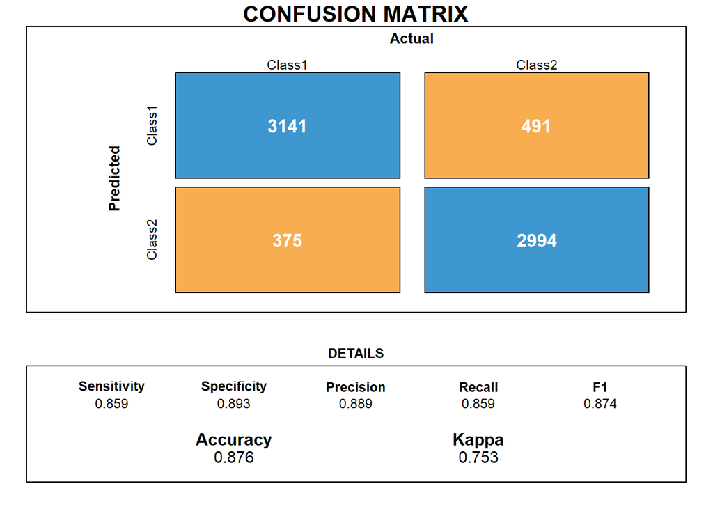

```r
cm.rf <- confusionMatrix(predict(modelo_rf), creditos.train.prep$Exited, positive = "churn")

draw_confusion_matrix(cm.rf)
```

La Sensitivity en el set de train fue de: **85.9110473%**

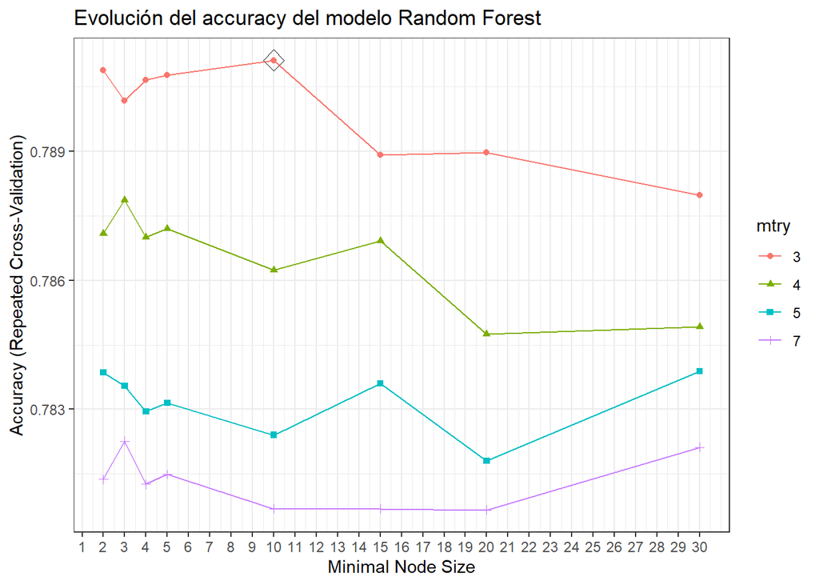

```r
# representación gráfica
ggplot(modelo_rf, highlight = TRUE) +
  scale_x_continuous(breaks = 1:30) +
  labs(title = "Evolución del accuracy del modelo Random Forest") +
  guides(color = guide_legend(title = "mtry"),
         shape = guide_legend(title = "mtry")) +
  theme_bw()
```

XGBoost

```r
cores <- detectCores()-1
cl <- makeCluster(cores, type = "SOCK")
registerDoSNOW(cl)

# hiperparametros, no. repeticiones y semilla para cada repeticion
particiones <- 10
repeticiones <- 5

hiperparametros <- expand.grid(eta = c(0.05, 0.075, 0.1),
                         nrounds = c(50, 75, 100),
                         max_depth = 6:8,
                         min_child_weight = c(2.0, 2.25, 2.5),
                         colsample_bytree = c(0.3, 0.4, 0.5),
                         gamma = 0,
                         subsample = 1)

set.seed(123)

seeds <- vector(mode = "list", length = (particiones * repeticiones) + 1)

for (i in 1:(particiones * repeticiones)) {
  seeds[[i]] <- sample.int(1000, nrow(hiperparametros))
  }

seeds[[(particiones * repeticiones) + 1]] <- sample.int(1000, 1)

# definicion del entrenamiento
control.train <- trainControl(method = "repeatedcv",
                              number = particiones,
                              repeats = repeticiones,
                              seeds = seeds,
                              returnResamp = "final",
                              verboseIter = FALSE,
                              search = "grid",
                              allowParallel = TRUE)

# ajuste del modelo
set.seed(342)

modelo_boost <- train(Exited ~ .,
                      data = creditos.train.prep,
                      method = "xgbTree",
                      tuneGrid = hiperparametros,
                      metric = "Accuracy",
                      trControl = control.train,
                      distribution = "adaboost",
                      verbose = FALSE)

# se guarda el modelo
saveRDS(modelo_boost, file = "modelo.xgb.rds")
```

```r
modelo_xgb <- readRDS(file = "Modelos_2/modelo.xgb.rds")
```

El accuracy promedio del modelo xgboost en el conjunto de entrenamiento fue de: **77.6005462%**

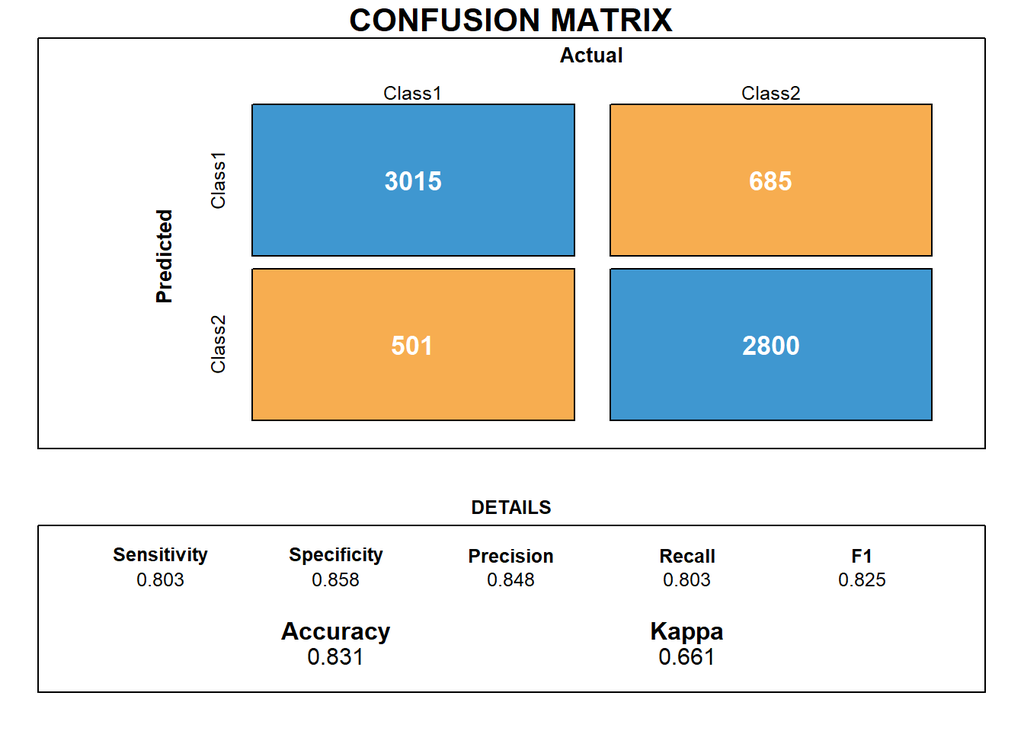

```r
cm.xgb <- confusionMatrix(predict(modelo_xgb), creditos.train.prep$Exited, positive = "churn")

draw_confusion_matrix(cm.xgb)
```

La Sensitivity en el set de train fue de: **80.3443329%**

Redes Neuronales (RNN)

```r
cores <- detectCores()-1
cl <- makeCluster(cores, type = "SOCK")
registerDoSNOW(cl)

# hiperparametros, no. repeticiones y semilla para cada repeticion
particiones <- 10
repeticiones <- 5

hiperparametros <- expand.grid(size = c(10, 20, 50, 80, 100, 120),
                               decay = c(0.0001, 0.1, 0.5))

set.seed(123)

seeds <- vector(mode = "list", length = (particiones * repeticiones) + 1)

for (i in 1:(particiones * repeticiones)) {
  seeds[[i]] <- sample.int(1000, nrow(hiperparametros))
  }

seeds[[(particiones * repeticiones) + 1]] <- sample.int(1000, 1)

# definicion del entrenamiento
control.train <- trainControl(method = "repeatedcv",
                              number = particiones,
                              repeats = repeticiones,
                              seeds = seeds,
                              returnResamp = "final",
                              verboseIter = FALSE,
                              allowParallel = TRUE)

# ajuste del modelo
set.seed(342)

modelo_nnet <- train(Exited ~ .,
                      data = creditos.train.prep,
                      method = "nnet",
                      tuneGrid = hiperparametros,
                      metric = "Accuracy",
                      trControl = control.train,
                      rang =c(-0.7, 0.7),
                      MaxNWts = 2000,
                      trace = FALSE)

# se guarda el modelo
saveRDS(modelo_nnet, file = "modelo.nnet.rds")
```

```r
modelo_nnet <- readRDS(file = "Modelos_2/modelo.nnet.rds")
```

El accuracy promedio del modelo nnet en el conjunto de entrenamiento fue de: **78.3753218%**

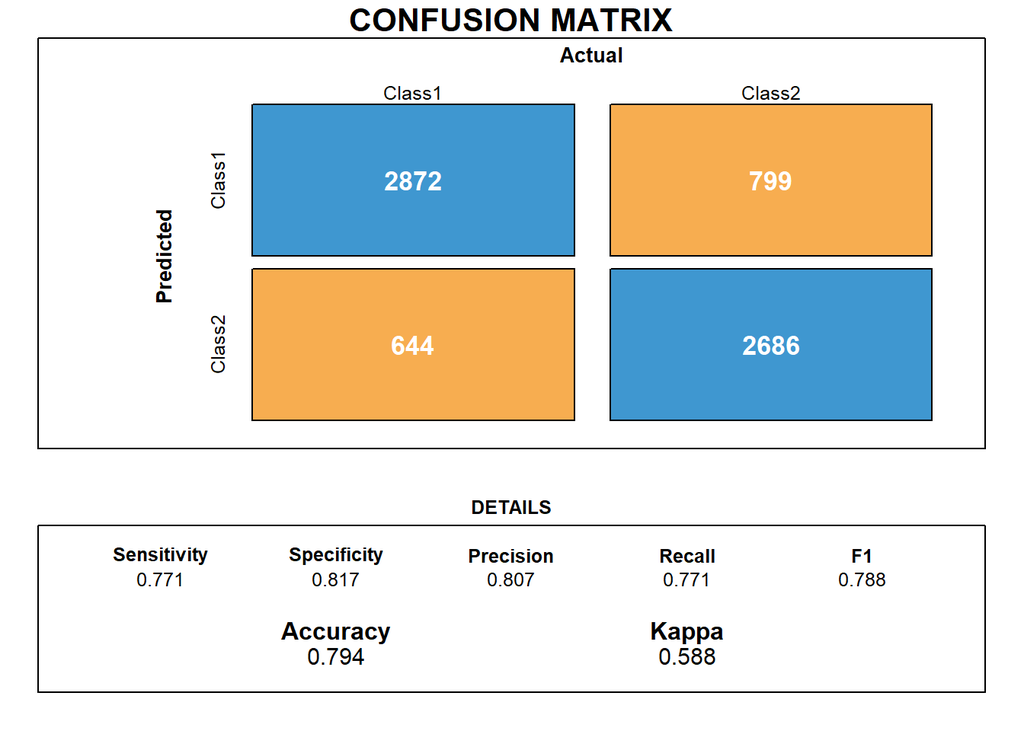

```r
cm.nnet <- confusionMatrix(predict(modelo_nnet), creditos.train.prep$Exited, positive = "churn")

draw_confusion_matrix(cm.nnet)
```

La Sensitivity en el set de train fue de: **77.0731707%**

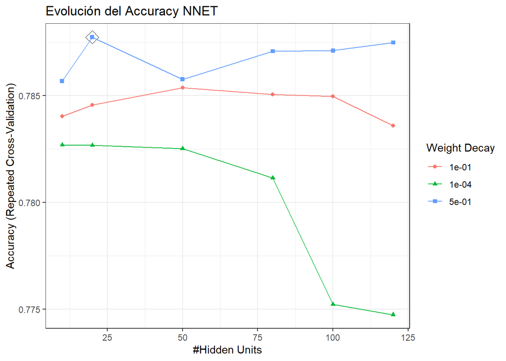

```r
# representación gráfica
ggplot(modelo_nnet, highlight = TRUE) +
  labs(title = "Evolución del Accuracy NNET") +
  theme_bw()
```

Gradient Boosting Machine (GBM)

```r
cores <- detectCores()-1
cl <- makeCluster(cores, type = "SOCK")
registerDoSNOW(cl)

# hiperparametros, no. repeticiones y semilla para cada repeticion
particiones <- 10
repeticiones <- 5

hiperparametros <- expand.grid(interaction.depth = c(1, 2),
                               n.trees = c(500, 1000, 2000),
                               shrinkage = c(0.001, 0.01, 0.1),
                               n.minobsinnode = c(2, 5, 15))

set.seed(123)

seeds <- vector(mode = "list", length = (particiones * repeticiones) + 1)

for (i in 1:(particiones * repeticiones)) {
  seeds[[i]] <- sample.int(1000, nrow(hiperparametros))
  }

seeds[[(particiones * repeticiones) + 1]] <- sample.int(1000, 1)

# definicion del entrenamiento
control.train <- trainControl(method = "repeatedcv",
                              number = particiones,
                              repeats = repeticiones,
                              seeds = seeds,
                              returnResamp = "final",
                              verboseIter = FALSE,
                              allowParallel = TRUE)

# ajuste del modelo
set.seed(342)

modelo_gbm <- train(Exited ~ .,
                      data = creditos.train.prep,
                      method = "gbm",
                      tuneGrid = hiperparametros,
                      metric = "Accuracy",
                      trControl = control.train,
                      distribution = "adaboost",
                      verbose = FALSE)

# se guarda el modelo
saveRDS(modelo_gbm, file = "modelo.gbm.rds")
```

```r
modelo_gbm <- readRDS(file = "Modelos_2/modelo.gbm.rds")
```

El accuracy promedio del modelo gbm en el conjunto de entrenamiento fue de: **76.1971264%**

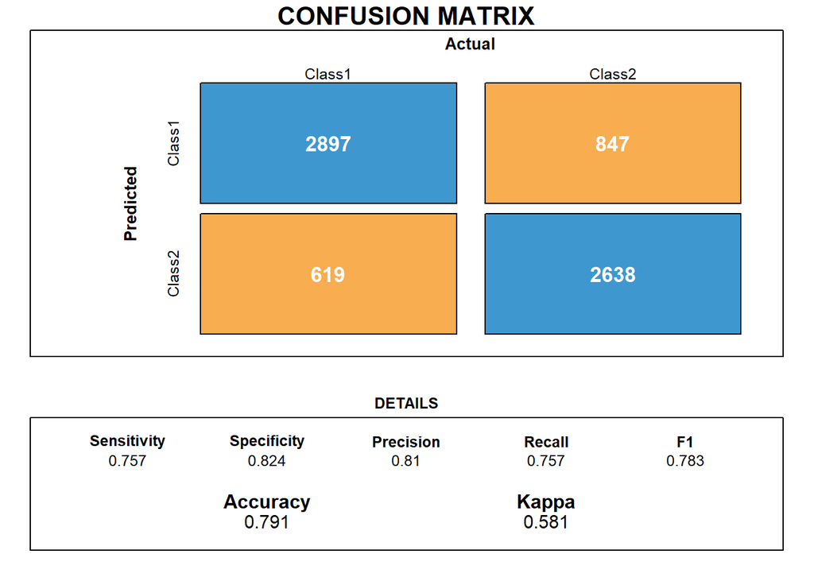

```r
cm.gbm <- confusionMatrix(predict(modelo_gbm), creditos.train.prep$Exited, positive = "churn")

draw_confusion_matrix(cm.gbm)
```

La Sensitivity en el set de train fue de: **75.6958393%**

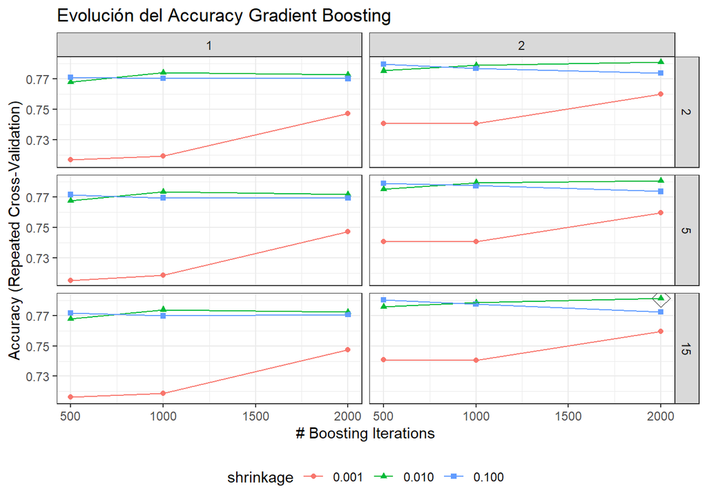

```r
# representación gráfica
ggplot(modelo_gbm, highlight = TRUE) +
  labs(title = "Evolución del Accuracy Gradient Boosting") +
  guides(color = guide_legend(title = "shrinkage"),
         shape = guide_legend(title = "shrinkage")) +
  theme_bw() +
  theme(legend.position = "bottom")
```

# Comparación de modelos

Finalmente, ya tenemos los modelos entrenados, por lo que, debemos identificar el que consigue mejores resultados para el problema que tenemos, que es el de predecir la fuga de clientes.

Con apoyo de gráficos veremos el Accuracy y la Sensitivity de cada modelo, para facilitar la identificación.

Accuracy

Antes de elaborar la primer gráfica correspondiente al Accuracy promedio, debemos identificar el **Accuracy basal**. En problemas de clasificación, es la moda de la variable objetivo, que en este caso es Exited. En la base que se está trabajando éste nivel basal está dado por la clase mayoritaria “0”, que representa el 0.7963, el cual es el nivel mínimo que deben superar los modelos. Para que un modelo predictivo sea útil, debe de tener un porcentaje de acierto superior a lo esperado por azar.

```r
prop.table(table(creditos$Exited))
```

```
##
##  churn   stay
## 0.2037 0.7963
```

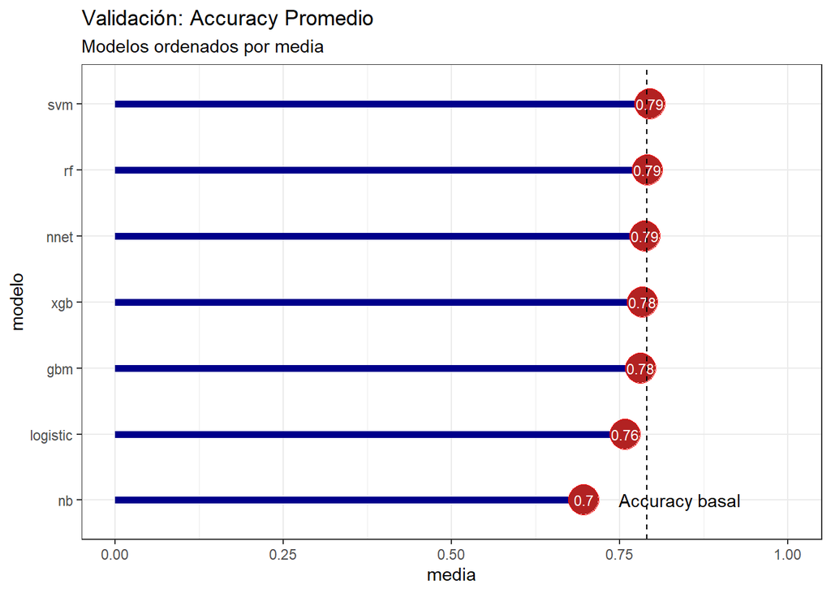

```r
models <- list(nb = modelo_nb,
               logistic = modelo_logistic,
               rf = modelo_rf,
               xgb = modelo_xgb,
               svm = modelo_svm,
               nnet = modelo_nnet,
               gbm = modelo_gbm
                )

resultados <- resamples(models)

metricas <- resultados$values %>%
  gather(key = "modelo", value = "valor", -Resample) %>%
  separate(col = "modelo", into = c("modelo", "metrica"), sep = "~", remove = TRUE)

metricas %>%
  filter(metrica == "Accuracy") %>%
  group_by(modelo) %>%
  summarise(media = mean(valor)) %>%
  ggplot(aes(x = reorder(modelo, media),
             y = media,
             label = round(media, 2))) +
  geom_segment(aes(x = reorder(modelo, media),
                   y = 0,
                   lwd = 2,
                   xend = modelo,
                   yend = media),
               color = "darkblue",
               lwd = 2) +
  geom_point(size = 8.5, pch = 21, bg = "firebrick", color = "red") +
  geom_text(color = "white", size = 3) +
  scale_y_continuous(limits = c(0, 1)) +
  geom_hline(yintercept = 0.79, linetype = "dashed") +
  annotate(geom = "text", y = 0.84, x = 1.0, label = "Accuracy basal") +
  labs(title = "Validación: Accuracy Promedio",
       subtitle = "Modelos ordenados por media",
       x = "modelo") +
  coord_flip() +
  theme_bw()
```

```r
metricas %>%
  group_by(modelo, metrica) %>%
  summarise(media = mean(valor)) %>%
  spread(key = metrica, value = media) %>%
  arrange(desc(Accuracy)) %>%
  kable(align = "c",
        caption = "Promedio: Accuracy - Kappa",
        format.args = list(big.mark = ","),
        ) %>%
  kable_paper("hover", full_width = F)
```

Promedio: Accuracy - Kappa

| modelo | Accuracy | Kappa |
| --- | --- | --- |
| svm | 0.7945747 | 0.5891222 |
| rf | 0.7911158 | 0.5821334 |
| nnet | 0.7877463 | 0.5754053 |
| xgb | 0.7840902 | 0.5680694 |
| gbm | 0.7812608 | 0.5623897 |
| logistic | 0.7578656 | 0.5156870 |
| nb | 0.6961301 | 0.3921686 |

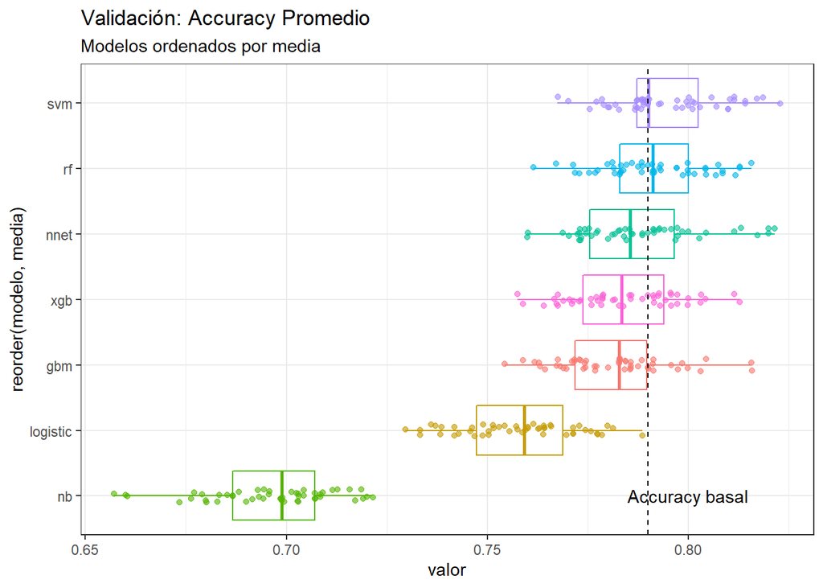

```r
metricas %>%
  filter(metrica == "Accuracy") %>%
  group_by(modelo) %>%
  mutate(media = mean(valor)) %>%
  ungroup() %>%
  ggplot(aes(x = reorder(modelo, media), y = valor, color = modelo)) +
  geom_boxplot(alpha = 0.6, outlier.shape = NA) +
  geom_jitter(width = 0.1, alpha = 0.6) +
  geom_hline(yintercept = 0.79, linetype = "dashed") +
  annotate(geom = "text", y = 0.8, x = 1.0, label = "Accuracy basal") +
  theme_bw() +
  labs(title = "Validación: Accuracy Promedio",
       subtitle = "Modelos ordenados por media") +
  coord_flip() +
  theme(legend.position = "none")
```

Sensitivity

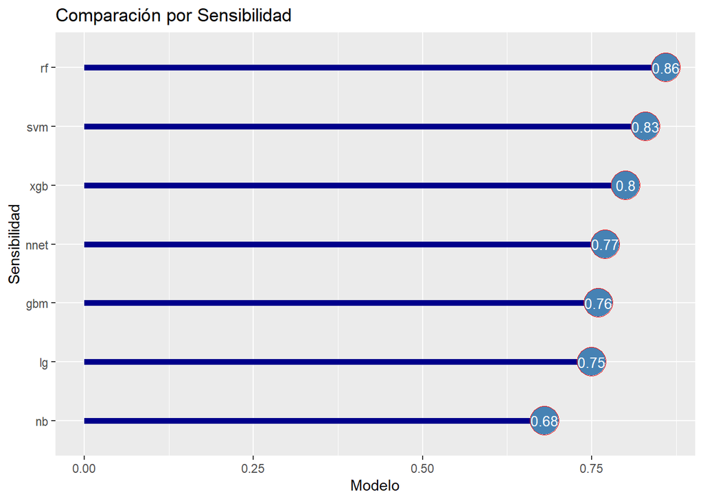

```r
s.nb <- round(cm.nb[["byClass"]][["Sensitivity"]], digits = 2)
s.lg <- round(cm.lg[["byClass"]][["Sensitivity"]], digits = 2)
s.svm <- round(cm.svm[["byClass"]][["Sensitivity"]], digits = 2)
s.rf <- round(cm.rf[["byClass"]][["Sensitivity"]], digits = 2)
s.xgb <- round(cm.xgb[["byClass"]][["Sensitivity"]], digits = 2)
s.nnet <- round(cm.nnet[["byClass"]][["Sensitivity"]], digits = 2)
s.gbm <- round(cm.gbm[["byClass"]][["Sensitivity"]], digits = 2)

comparacion.train <- tribble(
  ~Modelo,~Sensibilidad,
  'nb', s.nb,
  'lg', s.lg,
  'svm', s.svm,
  'rf', s.rf,
  'xgb', s.xgb,
  'nnet', s.nnet,
  'gbm', s.gbm
  )

comparacion.train$Modelo <- factor(comparacion.train$Modelo,
                                  levels = comparacion.train$Modelo
                                  [order(comparacion.train$Sensibilidad)])

comparacion.train %>%
  ggplot(aes(x = Modelo, y = Sensibilidad)) +
  geom_segment(aes(x = Modelo, xend = Modelo, y = 0, yend = Sensibilidad),
               color = "darkblue", lwd = 2) +
  geom_point(size = 9.5, pch = 21, bg = "steelblue", col = "red") +
  geom_text(aes(label = Sensibilidad), color = "white", size = 3.5) +
  labs(title = "Comparación por Sensibilidad",
       y = "Modelo",
       x = "Sensibilidad") +
  coord_flip()
```

Nuevamente, los modelos que no superaron el Accuracy basal presentan la Sensitivity más bajas.

# Evaluación con datos de validación

A pesar de que algunos modelos tuvieron buen desempeño, la evaluación final se debe de hacer con un conjunto de observaciones diferente, porque son observaciones que los algoritmos no han visto, además, esto nos permitirá conocer si los modelos generaron sobreajuste.

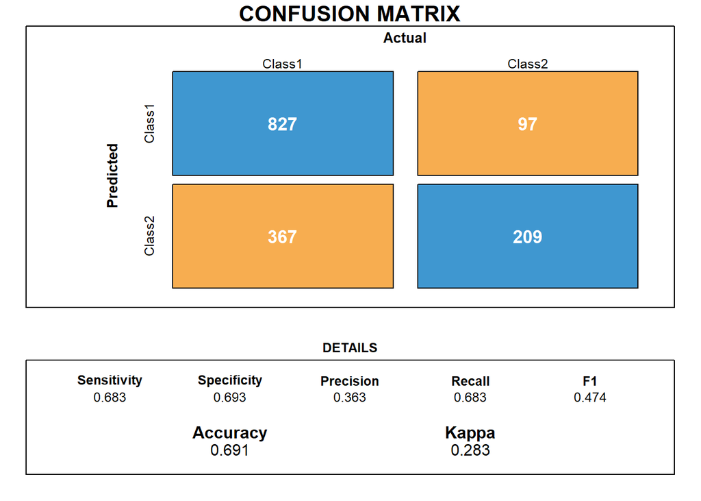

```r
# Naive Bayes

preds.nb <- predict(modelo_nb, creditos.validacion.prep)
cm.nb.val <- confusionMatrix(preds.nb, creditos.validacion.prep$Exited, positive = "churn")
draw_confusion_matrix(cm.nb.val)
```

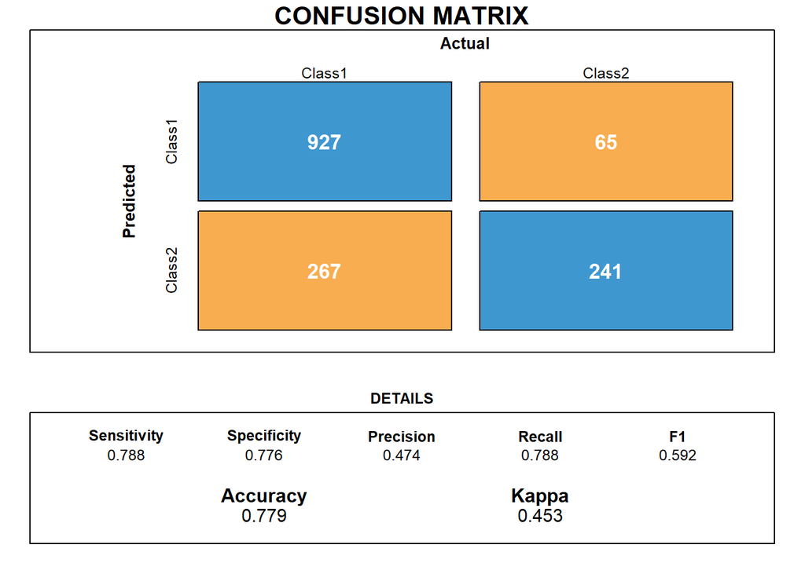

```r
# Logistic Regression

preds.log <- predict(modelo_logistic, creditos.validacion.prep)
cm.lg.val <- confusionMatrix(preds.log, creditos.validacion.prep$Exited, positive = "churn")
draw_confusion_matrix(cm.lg.val)
```

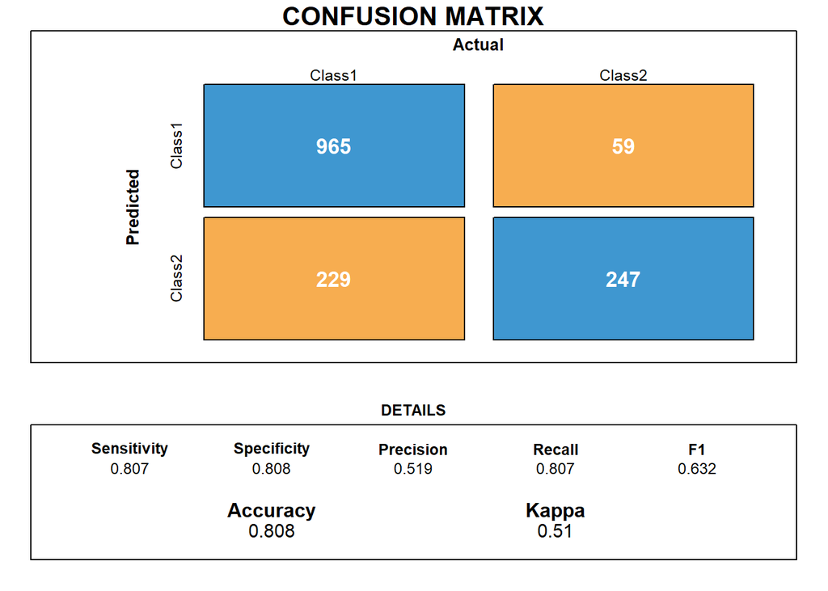

```r
# Suport Vector Machine

preds.svm <- predict(modelo_svm, creditos.validacion.prep)
cm.svm.val <- confusionMatrix(preds.svm, creditos.validacion.prep$Exited, positive = "churn")
draw_confusion_matrix(cm.svm.val)
```